# Predicting Recipe for Taste Bytes Homepage

Building classification models to predict the recipe for enhancing website traffic

Aravindh Venkatraman

21 October 2025

# Table of Contents

Statements  
Executive Summary

1. Introduction
2. Aim and Methodology of this Project
3. Exploratory Data Analysis - EDA
4. Machine Learning Model
5. Model Results & Discussion
6. Business Focus and Metric Evaluation
7. Conclusion, Recommendations & Next Steps

# Statements

**Acknowledgement**  
I sincerely thank my parents and family for their unwavering support and encouragement, which enabled me to dedicate my time and effort to learning Machine Learning and Artificial Intelligence and applying them to environmental management challenges. I thank the Google Career Certification and Datacamp Certification courses for providing me the comprehensive resources and guidance to enhance my skills in Python, R Programming, and Machine Learning Concepts.

**Use of generative artificial intelligence**  
Generative Artificial Intelligence (GenAI) tools were primarily used to assist in creating visualization, refining charts, and adjusting plotting parameters. In addition, GenAI was used for helping me write, debug code and improve workflow efficiency. All outputs generated by GenAI were carefully reviewed, modified and evaluated before implementation to ensure scientific accuracy, reliability, and alignment with the research objectives.

**Ethical Consideration and Transparency**  
This research was conducted with transparency, rigor, and ethical responsibility. All computational methods and analyses were independently validated, and any use of automated or AI-assisted tools was fully disclosed. The methodologies and code are provided to ensure reproducibility and facilitate future research.

**Data and Code Availability**  
Where applicable, datasets, code scripts, and analysis workflows used in this research are openly available upon request or in public repositories, supporting transparency and reproducibility in computational environmental management research.

# Executive Summary

**Problem Statement**  
Recipe displays on the Tasty Bytes homepage are chosen subjectively, leading to inconsistent customer engagement and low traffic to the website. When a popular recipe is displayed, overall site traffic increases by up to 40%, assuming that it drives more subscriptions. However, the team lacks a systematic way to predict which recipes will generate high traffic.

**Project Aim and Focus**  
The aim of the project is to develop a data-driven prediction systems that identifies which recipes will lead to high homepage traffic. The focus is on achieving at least 80% accuracy in correctly predicting high-traffic recipes, thereby supporting subscription growth and improving user engagement.

**Raw data used**  
The project uses a dataset (`recipe_site_traffic_2212.csv`) which includes variables such as, recipe, nutrient contributions and servings for the recipe, recipe category, website traffic for the recipe.

**Methodology**  
The project applies classification machine learning models to predict popular recipes for increasing customer engagement and thereby subscriptions. Key steps include:

- Data Exploration and Preprocessing
- Feature Analysis and Selection
- Model Selection, Development and Training
- Model Evaluation and Training
- Deployment
- Iteration & Monitoring

This project demonstrates how data-driven approaches can provide actionable insights to Tasty Bytes, enabling smarter recipe selection and promoting customer engagement and subscriptions.

**Results/Key Findings:**

- **Recipe category drives traffic:** Vegetables and Potato recipes consistently attract high traffic, while Beverages, Breakfast, and Chicken generally see lower engagement.
- **Nutrients and servings have secondary impact:** Protein content shows modest influence; calories, carbohydrates, sugar, and serving size are less predictive.
- **Model performance:** Logistic Regression achieved the highest ROC-AUC (0.801), while Random Forest and XGBoost provide robust, balanced predictions. Decision Tree offers interpretable insights but slightly lower predictive power.

**Recommendations:**

1. **Focus on high-traffic categories** (Vegetables, Potato) in recipe development and promotion.
2. **Use ensemble models** (Random Forest/XGBoost) to predict recipe popularity and guide recommendations.
3. **Enhance engagement for lower-traffic categories** through innovative recipes, nutritional highlights, or combined promotions.
4. **Leverage protein and other nutrient information** to personalize recommendations for health-conscious users.
5. **Optimize marketing and UX strategies** based on predicted traffic to increase recipe visibility and user engagement.

**Next Steps:**

- Integrate predictive models into the Tasty Bytes platform for real-time traffic estimation.
- Monitor model performance regularly and retrain with new traffic data.
- Explore additional features (ratings, seasonality, prep time) to improve predictions.
- Conduct A/B testing to validate category-driven promotion strategies.
- Develop campaigns to boost engagement for under performing categories.
- **Impact:** By focusing on predictive insights, Tasty Bytes can maximize user engagement, optimize content strategy, and make data-driven decisions for recipe promotion.

# 1 Introduction

Tasty Bytes was founded in 2020 during the Covid-19 pandemic to inspire people with recipes using limited home supplies. Today, it offers meal plans and ingredient delivery through a subscription service.

To boost user engagement, Tasty Bytes aims to feature recipes that attract high website traffic. Currently, recipe selection is subjective, leading to inconsistent results. Data shows that featuring popular recipes can increase total traffic by up to 40%, directly influencing subscriptions. Using machine learning on available recipe dataset, the platform can predict high-traffic recipes and make data-driven homepage decisions, improving traffic and subscriptions.

# 2 Project Aim and Focus

The goal of this project was to identify which recipes are likely to generate high website traffic and to develop a model that can correctly predict high-traffic recipes at least 80% of the time. This directly supports data-driven homepage selection to boost customer engagement and subscriptions.

## 2.1 Methodology

The study applies binary classification to predict recipe traffic (`High` vs `Low`) using recipe attributes.

**Key steps include:**

- **Data Preparation:** Cleaning, encoding, and validating recipe dataset.
- **Exploratory Data Analysis (EDA):** Identifying key relationships between recipe variables through data analysis and visualization
- **Modelling:** Training machine learning models with cross-validation.
- **Evaluation:** Comparing models using Accuracy, Precision, Recall, F1-score, and ROC-AUC to identify the best-performing approach.
- **Business KPI alignment:** Evaluating model results against key business indicators such as Recall, Accuracy, and F1 Score for only High Traffic recipe predictions - to ensure predictions translate into measurable engagement and subscription impact.

This approach ensures that model insights are both technically robust and practically relevant for optimizing recipe promotion on the Tasty Bytes homepage.

# 3 Exploratory Data Analysis - EDA

First, load the necessary libraries in R that are essential for the success of the *“Predicting Recipe for Taste Bytes Homepage”* project. These include packages for data handling, analysis, processing, visualization, machine learning, and model evaluation.

```r
# Operational libraries
library(tidyverse)      # Data manipulation and visualization
library(dplyr)          # Data manipulation
library(broom)              # Data tidying

# Visualization
library(ggplot2)        # Powerful and flexible plotting
library(GGally)         # Pair plot
library(ggfortify)      # PLotting customization
library(RColorBrewer)   # Color Customization
library(viridis)        # Color Customization
library(naniar)         # Visualize missing values
library(kableExtra)     # Table styling
library(corrplot)       # Correlation plots
library(patchwork)      # Arranging multiple plots
library(Ckmeans.1d.dp)  # Decision tree required
library(DiagrammeR)     # Decision tree required

# Modelling
library(caret)          # Splitting dataset and model evaluation
library(glmnet)         # Regularized logistic regression
library(rpart)          # Decision tree
library(rpart.plot)     # Plot the decision tree
library(randomForest)   # Random Forest Model
library(xgboost)        # Gradient boosting Model
library(pROC)           # ROC curves and AUC metrics
```

## 3.1 Data loading and exploration

The first step of the project involves exploring the distribution of features in the dataset `recipe_site_traffic_2212.csv`.

The dataset consists of 947 observations across 8 variables, with the following data variables:

- **`recipe:`** unique identifier for each recipe;
- **`category:`** defines the type of `recipe` and are listed in one of eleven possible groupings;
- **`servings:`** number of servings;
- **Nutrient Composition (`calories, carbohydrates, sugar, protein`):** nutrient content per recipe; as the range of each variables are consistent with per recipe values.
- **Target Variable (`high_traffic`):** recipe popularity.

Data Types of these variables,

- **Numeric:** 4 variables
- **Integer:** 1 variable
- **Character:** 3 variables

```r
path <- "D:/Study/Machine Learning/Projects/Completed projects for GitHub/Predict-popular-recipes-to-boost-traffic-to-the-Tasty-Bytes-homepage/Raw Data/recipe_site_traffic_2212.csv"

# Load the dataset
recipe_df <- read.csv(path)

# Checking th structure and dataset
str(recipe_df)
```

```
## 'data.frame':    947 obs. of  8 variables:
##  $ recipe      : int  1 2 3 4 5 6 7 8 9 10 ...
##  $ calories    : num  NA 35.5 914.3 97 27.1 ...
##  $ carbohydrate: num  NA 38.56 42.68 30.56 1.85 ...
##  $ sugar       : num  NA 0.66 3.09 38.63 0.8 ...
##  $ protein     : num  NA 0.92 2.88 0.02 0.53 ...
##  $ category    : chr  "Pork" "Potato" "Breakfast" "Beverages" ...
##  $ servings    : chr  "6" "4" "1" "4" ...
##  $ high_traffic: chr  "High" "High" NA "High" ...
```

```r
# Reading the Dataset
kable(head(recipe_df), caption = "Recipe site traffic dataset") %>%
  kable_styling(full_width = F, position = "left")
```

Recipe site traffic dataset

| recipe | calories | carbohydrate | sugar | protein | category | servings | high_traffic |
| --- | --- | --- | --- | --- | --- | --- | --- |
| 1 | NA | NA | NA | NA | Pork | 6 | High |
| 2 | 35.48 | 38.56 | 0.66 | 0.92 | Potato | 4 | High |
| 3 | 914.28 | 42.68 | 3.09 | 2.88 | Breakfast | 1 | NA |
| 4 | 97.03 | 30.56 | 38.63 | 0.02 | Beverages | 4 | High |
| 5 | 27.05 | 1.85 | 0.80 | 0.53 | Beverages | 4 | NA |
| 6 | 691.15 | 3.46 | 1.65 | 53.93 | One Dish Meal | 2 | High |

The dataset contains variables with,

- Different data types which will be converted to relevant data types.
- Changing the all the character observations to small letters for consistency.
- There are no negative values in any of the variables.
- Missing values, which need to be carefully analyzed and appropriately imputed before further analysis.

```r
# Converting the datatypes for efficient analysis
suppressWarnings(
    recipe_df$servings <- as.numeric(recipe_df$servings)
)
suppressWarnings(
    recipe_df$category <- as.factor(recipe_df$category)
)
suppressWarnings(
    recipe_df$high_traffic <- as.factor(recipe_df$high_traffic)
)

# Checking the structure and summary stats
str(recipe_df)
```

```
## 'data.frame':    947 obs. of  8 variables:
##  $ recipe      : int  1 2 3 4 5 6 7 8 9 10 ...
##  $ calories    : num  NA 35.5 914.3 97 27.1 ...
##  $ carbohydrate: num  NA 38.56 42.68 30.56 1.85 ...
##  $ sugar       : num  NA 0.66 3.09 38.63 0.8 ...
##  $ protein     : num  NA 0.92 2.88 0.02 0.53 ...
##  $ category    : Factor w/ 11 levels "Beverages","Breakfast",..: 9 10 2 1 1 8 4 6 9 3 ...
##  $ servings    : num  6 4 1 4 4 2 4 4 6 2 ...
##  $ high_traffic: Factor w/ 1 level "High": 1 1 NA 1 NA 1 NA NA 1 NA ...
```

```r
# Statistical Summary of the dataset
kable(summary(recipe_df), caption = "Descriptive Statistics of Recipe Dataset") %>%
  kable_styling(full_width = F, position = "left")
```

Descriptive Statistics of Recipe Dataset

|  | recipe | calories | carbohydrate | sugar | protein | category | servings | high_traffic |
| --- | --- | --- | --- | --- | --- | --- | --- | --- |
|  | Min. : 1.0 | Min. : 0.14 | Min. : 0.030 | Min. : 0.010 | Min. : 0.000 | Breakfast :106 | Min. :1.000 | High:574 |
|  | 1st Qu.:237.5 | 1st Qu.: 110.43 | 1st Qu.: 8.375 | 1st Qu.: 1.690 | 1st Qu.: 3.195 | Chicken Breast: 98 | 1st Qu.:2.000 | NA’s:373 |
|  | Median :474.0 | Median : 288.55 | Median : 21.480 | Median : 4.550 | Median : 10.800 | Beverages : 92 | Median :4.000 | NA |
|  | Mean :474.0 | Mean : 435.94 | Mean : 35.070 | Mean : 9.047 | Mean : 24.149 | Lunch/Snacks : 89 | Mean :3.474 | NA |
|  | 3rd Qu.:710.5 | 3rd Qu.: 597.65 | 3rd Qu.: 44.965 | 3rd Qu.: 9.800 | 3rd Qu.: 30.200 | Potato : 88 | 3rd Qu.:4.000 | NA |
|  | Max. :947.0 | Max. :3633.16 | Max. :530.420 | Max. :148.750 | Max. :363.360 | Pork : 84 | Max. :6.000 | NA |
|  | NA | NA’s :52 | NA’s :52 | NA’s :52 | NA’s :52 | (Other) :390 | NA’s :3 | NA |

### 3.1.1 Variable Analysis

**`recipe` Duplicate & Missing Values:** The dataset was checked for duplicates within the recipe variable, and no duplicate records were found.

**Recipe `category`:** The recipe category was converted to factor and found 11 unique recipe categories in the dataset. Categories are relatively balanced, each representing approximately 8 – 11% of the dataset.

```r
# Check for duplicate values in the recipe variable
suppressWarnings(duplicate_vals <- sum(duplicated(recipe_df$recipe)))
missing_recipe <- sum(recipe_df$recipe == "")
cat("Number of duplicate values in the `recipe` variable:", duplicate_vals, "\n")
```

```
## Number of duplicate values in the `recipe` variable: 0
```

```r
cat("Number of missing values in the `recipe` variable:", missing_recipe, "\n\n")
```

```
## Number of missing values in the `recipe` variable: 0
```

```r
# Changing the obsservation to small letters
recipe_df <- recipe_df %>%
  mutate(category = str_to_lower(category)) %>%
  mutate(high_traffic = str_to_lower(high_traffic))

# Check for unique values in the recipe category variable
unique_cat <- unique(recipe_df$category)

cat("Total number of entries in the recipe `category` variable:", nrow(recipe_df), "\n")
```

```
## Total number of entries in the recipe `category` variable: 947
```

```r
cat("Number of unique recipe categories:", length(unique_cat), "\n")
```

```
## Number of unique recipe categories: 11
```

```r
cat("Categories after conversion to factor:", paste(levels(recipe_df$category), collapse = ", "), "\n\n")
```

```
## Categories after conversion to factor:
```

```r
# Count frequency of each category in descending order
category_counts <- table(recipe_df$category)
category_percent <- round(100 * category_counts / sum(category_counts), 2)
# Print counts with percentages
for(i in seq_along(category_counts)) {
  cat(names(category_counts)[i], ":", category_counts[i],
      "(", category_percent[i], "%)\n")
}
```

```
## beverages : 92 ( 9.71 %)
## breakfast : 106 ( 11.19 %)
## chicken : 74 ( 7.81 %)
## chicken breast : 98 ( 10.35 %)
## dessert : 83 ( 8.76 %)
## lunch/snacks : 89 ( 9.4 %)
## meat : 79 ( 8.34 %)
## one dish meal : 71 ( 7.5 %)
## pork : 84 ( 8.87 %)
## potato : 88 ( 9.29 %)
## vegetable : 83 ( 8.76 %)
```

**Summarizing the missing values in the dataset**

Out of 947 rows,

- `rows_with_any_na` = 414 rows contain missing values.
- `rows_traffic_na` = 373 rows contain missing values in the traffic column.
- `rows_nutrients_na` = 52 rows contain missing values in the nutrient variables (calorie, carbohydrate, sugar and protein), all occurring in the same rows.
- `rows_ser` = 3 rows contain missing values in the servings column, only in the Lunch/Snack recipe category.

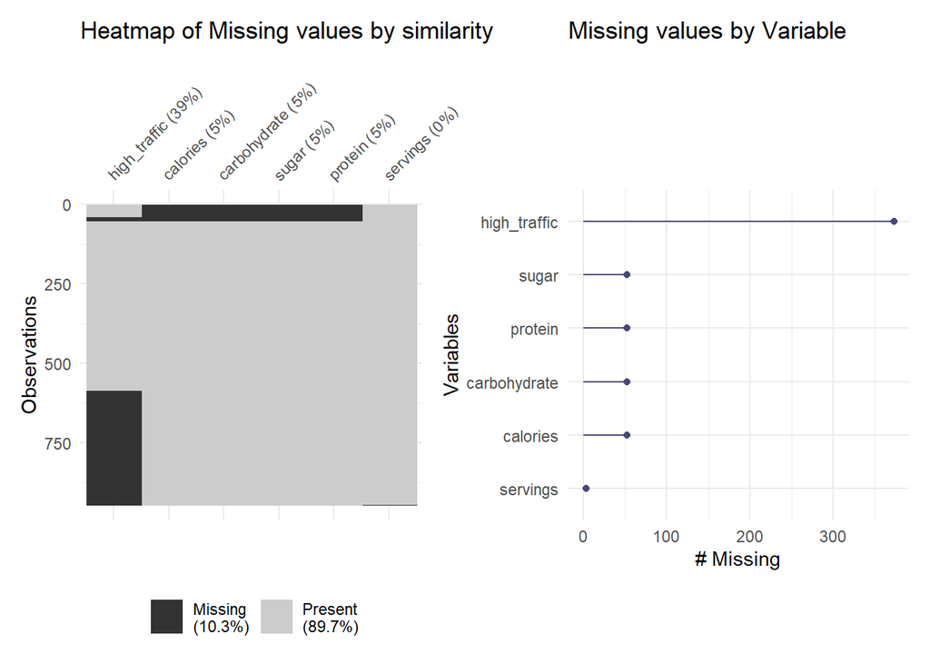

```r
# Visualizing the missing values
recipe_miss <- recipe_df %>%
  select(where(~ any(is.na(.))))

miss_h_p1 <- vis_miss(recipe_miss, cluster = TRUE, sort_miss = TRUE) +
  ggtitle("Heatmap of Missing values by similarity")
miss_h_p2 <- gg_miss_var(recipe_miss) +
  ggtitle("Missing values by Variable")

# Plotting
miss_h_p1 + miss_h_p2
```

```r
# Missing data summary grouped by category
nutrient_vars <- c("calories", "carbohydrate", "sugar", "protein")

missing_summary <- recipe_df %>%
  summarize(
    total_rows = as.integer(n()), # total rows
    rows_with_any_na = sum((if_any(everything(), is.na))), # Rows with any NAs
    rows_traffic_na = sum(is.na(high_traffic)), # Rows with traffic NAs
    rows_nutrient_na = sum(if_all(all_of(nutrient_vars), is.na)), # Rows with NAs in nutrient variables
    rows_ser_na = sum(is.na(servings)) # Rows with NAs in servings variables
  )

kable(missing_summary, caption = "Distribution of Missing values - Recipe Dataset") %>%
  kable_styling(full_width = F, position = "left")
```

Distribution of Missing values - Recipe Dataset

| total_rows | rows_with_any_na | rows_traffic_na | rows_nutrient_na | rows_ser_na |
| --- | --- | --- | --- | --- |
| 947 | 414 | 373 | 52 | 3 |

### 3.1.2 Missing Values Imputation

To achieve Tasty Bytes’ goal of selecting homepage recipes that attract the highest website traffic, missing data was carefully imputed to ensure consistency, fairness, and reliability in prediction. The approach focuses on using nutrient values per serving, allowing recipes of different serving sizes to be compared on an equal scale.

```r
# Generate the corresponding per_serving column names
nutrient_vars_per_serving <- paste0(nutrient_vars, "_per_serving")

# Calculating the nutrient composition per serving for all observations
recipe_df <- recipe_df %>%
  group_by(category) %>%
  mutate(across(all_of(nutrient_vars),
                ~ .x / servings,
                .names = "{.col}_per_serving")) %>%
  mutate(round(across(all_of(nutrient_vars_per_serving),
                ~ ifelse(is.na(.x), mean(.x, na.rm = TRUE), .x)), 2)) %>%
  ungroup()

kable(head(recipe_df), caption = "Distribution of Missing values - Recipe Dataset") %>%
  kable_styling(full_width = F, position = "left")
```

Distribution of Missing values - Recipe Dataset

| recipe | calories | carbohydrate | sugar | protein | category | servings | high_traffic | calories_per_serving | carbohydrate_per_serving | sugar_per_serving | protein_per_serving |
| --- | --- | --- | --- | --- | --- | --- | --- | --- | --- | --- | --- |
| 1 | NA | NA | NA | NA | pork | 6 | high | 241.55 | 11.39 | 3.02 | 15.89 |
| 2 | 35.48 | 38.56 | 0.66 | 0.92 | potato | 4 | high | 8.87 | 9.64 | 0.16 | 0.23 |
| 3 | 914.28 | 42.68 | 3.09 | 2.88 | breakfast | 1 | NA | 914.28 | 42.68 | 3.09 | 2.88 |
| 4 | 97.03 | 30.56 | 38.63 | 0.02 | beverages | 4 | high | 24.26 | 7.64 | 9.66 | 0.00 |
| 5 | 27.05 | 1.85 | 0.80 | 0.53 | beverages | 4 | NA | 6.76 | 0.46 | 0.20 | 0.13 |
| 6 | 691.15 | 3.46 | 1.65 | 53.93 | one dish meal | 2 | high | 345.58 | 1.73 | 0.82 | 26.96 |

**Traffic (`traffic`):**

The traffic variable had only `High` traffic values recorded, meaning the missing values corresponds to not `High` traffic, i.e. `Low` traffic. These missing values were systematically imputed as `Low`, following the business logic that unrecorded traffic likely indicates Low engagement. This ensures that both traffic classes (`High` and `Low`) are represented for accurate model training and balanced classification.

```r
# Traffic NAs - Imputing all the missing values with `Low`
miss_traffic <- recipe_df %>%
filter(is.na(high_traffic))

kable(head(miss_traffic), caption = "Missing values - Traffic Variable") %>%
  kable_styling(full_width = F, position = "left")
```

Missing values - Traffic Variable

| recipe | calories | carbohydrate | sugar | protein | category | servings | high_traffic | calories_per_serving | carbohydrate_per_serving | sugar_per_serving | protein_per_serving |
| --- | --- | --- | --- | --- | --- | --- | --- | --- | --- | --- | --- |
| 3 | 914.28 | 42.68 | 3.09 | 2.88 | breakfast | 1 | NA | 914.28 | 42.68 | 3.09 | 2.88 |
| 5 | 27.05 | 1.85 | 0.80 | 0.53 | beverages | 4 | NA | 6.76 | 0.46 | 0.20 | 0.13 |
| 7 | 183.94 | 47.95 | 9.75 | 46.71 | chicken breast | 4 | NA | 45.98 | 11.99 | 2.44 | 11.68 |
| 8 | 299.14 | 3.17 | 0.40 | 32.40 | lunch/snacks | 4 | NA | 74.78 | 0.79 | 0.10 | 8.10 |
| 10 | 248.28 | 48.54 | 3.99 | 113.85 | chicken | 2 | NA | 124.14 | 24.27 | 2.00 | 56.92 |
| 11 | 170.12 | 17.63 | 4.10 | 0.91 | beverages | 1 | NA | 170.12 | 17.63 | 4.10 | 0.91 |

```r
suppressWarnings(
    recipe_imp <- recipe_df %>%
    mutate(high_traffic = factor(
    if_else(is.na(high_traffic), "low", high_traffic),
    levels = c("low", "high")))
)

# Logical vector of missing rows
missing_traffic <- is.na(recipe_df$high_traffic)

# Filter the same rows after imputation
traffic_imp <- recipe_imp %>% filter(missing_traffic) %>% head()

kable(traffic_imp, caption = "Imputation of Missing values - Traffic Variable") %>%
  kable_styling(full_width = F, position = "left")
```

Imputation of Missing values - Traffic Variable

| recipe | calories | carbohydrate | sugar | protein | category | servings | high_traffic | calories_per_serving | carbohydrate_per_serving | sugar_per_serving | protein_per_serving |
| --- | --- | --- | --- | --- | --- | --- | --- | --- | --- | --- | --- |
| 3 | 914.28 | 42.68 | 3.09 | 2.88 | breakfast | 1 | low | 914.28 | 42.68 | 3.09 | 2.88 |
| 5 | 27.05 | 1.85 | 0.80 | 0.53 | beverages | 4 | low | 6.76 | 0.46 | 0.20 | 0.13 |
| 7 | 183.94 | 47.95 | 9.75 | 46.71 | chicken breast | 4 | low | 45.98 | 11.99 | 2.44 | 11.68 |
| 8 | 299.14 | 3.17 | 0.40 | 32.40 | lunch/snacks | 4 | low | 74.78 | 0.79 | 0.10 | 8.10 |
| 10 | 248.28 | 48.54 | 3.99 | 113.85 | chicken | 2 | low | 124.14 | 24.27 | 2.00 | 56.92 |
| 11 | 170.12 | 17.63 | 4.10 | 0.91 | beverages | 1 | low | 170.12 | 17.63 | 4.10 | 0.91 |

**Nutrient Composition per recipe (`calories, carbohydrate, sugar, protein`):**

Nutrient per recipe values were normalized per serving using:

`Nutrient value per serving = Nutrient value per recipe / Number of servings`

Missing nutrient per serving values were filled with the mean nutrient per serving of the same category (e.g., average for “Desserts” or “Seafood”). Total nutrient per recipe values were then reconstructed by multiplying these averages by the number of servings. This ensures nutrient per recipe values are consistent and comparable across recipes, regardless of serving size.

```r
# Nutrient Composition - Imputing the missing values
miss_nutrients <- recipe_df %>%
filter(if_all(all_of(nutrient_vars), is.na))

kable(head(miss_nutrients), caption = "Missing values - Nutrient Variable") %>%
  kable_styling(full_width = F, position = "left")
```

Missing values - Nutrient Variable

| recipe | calories | carbohydrate | sugar | protein | category | servings | high_traffic | calories_per_serving | carbohydrate_per_serving | sugar_per_serving | protein_per_serving |
| --- | --- | --- | --- | --- | --- | --- | --- | --- | --- | --- | --- |
| 1 | NA | NA | NA | NA | pork | 6 | high | 241.55 | 11.39 | 3.02 | 15.89 |
| 24 | NA | NA | NA | NA | meat | 2 | NA | 253.13 | 10.06 | 2.45 | 16.43 |
| 49 | NA | NA | NA | NA | chicken breast | 4 | NA | 240.08 | 8.79 | 2.39 | 22.64 |
| 83 | NA | NA | NA | NA | meat | 4 | high | 253.13 | 10.06 | 2.45 | 16.43 |
| 90 | NA | NA | NA | NA | pork | 6 | high | 241.55 | 11.39 | 3.02 | 15.89 |
| 117 | NA | NA | NA | NA | chicken breast | 6 | high | 240.08 | 8.79 | 2.39 | 22.64 |

```r
suppressWarnings(
recipe_imp <- recipe_imp %>%
  rowwise() %>%
  mutate(across(
    all_of(nutrient_vars),
    ~ ifelse(is.na(.x),
             c_across(all_of(paste0(cur_column(), "_per_serving"))) * servings, .x))) %>%
  ungroup()
)

# Logical vector of missing nutrient rows
missing_nutrients <- apply(recipe_df[, nutrient_vars], 1, function(x) all(is.na(x)))

# Filter the same rows after imputation
nutrient_imp <- recipe_imp %>% filter(missing_nutrients) %>% head()

kable(nutrient_imp, caption = "Imputation of Missing values - Nutrient Variable") %>%
  kable_styling(full_width = F, position = "left")
```

Imputation of Missing values - Nutrient Variable

| recipe | calories | carbohydrate | sugar | protein | category | servings | high_traffic | calories_per_serving | carbohydrate_per_serving | sugar_per_serving | protein_per_serving |
| --- | --- | --- | --- | --- | --- | --- | --- | --- | --- | --- | --- |
| 1 | 1449.30 | 68.34 | 18.12 | 95.34 | pork | 6 | high | 241.55 | 11.39 | 3.02 | 15.89 |
| 24 | 506.26 | 20.12 | 4.90 | 32.86 | meat | 2 | low | 253.13 | 10.06 | 2.45 | 16.43 |
| 49 | 960.32 | 35.16 | 9.56 | 90.56 | chicken breast | 4 | low | 240.08 | 8.79 | 2.39 | 22.64 |
| 83 | 1012.52 | 40.24 | 9.80 | 65.72 | meat | 4 | high | 253.13 | 10.06 | 2.45 | 16.43 |
| 90 | 1449.30 | 68.34 | 18.12 | 95.34 | pork | 6 | high | 241.55 | 11.39 | 3.02 | 15.89 |
| 117 | 1440.48 | 52.74 | 14.34 | 135.84 | chicken breast | 6 | high | 240.08 | 8.79 | 2.39 | 22.64 |

**Servings (`servings`):**

Three missing values were identified in the `Lunch/Snack` recipe category and were imputed using nutrient per recipe to nutrient per serving ratios. For each recipe, total nutrient per recipe (`calories, carbohydrate, sugar, and protein`) were divided by their respective nutrient per serving values. The average of these ratios, rounded to the nearest whole number, was used as the imputed serving size. Nutrient per serving values of these particular three observations were then recalculated using the imputed serving sizes, ensuring realistic and category-consistent portions.

```r
# Servings - Imputing the missing values in Lunch/Snack Category
miss_ser <- recipe_df %>%
filter(is.na(servings))

kable(miss_ser, caption = "Missing values - Servings Variable") %>%
  kable_styling(full_width = F, position = "left")
```

Missing values - Servings Variable

| recipe | calories | carbohydrate | sugar | protein | category | servings | high_traffic | calories_per_serving | carbohydrate_per_serving | sugar_per_serving | protein_per_serving |
| --- | --- | --- | --- | --- | --- | --- | --- | --- | --- | --- | --- |
| 452 | 1542.53 | 14.73 | 5.71 | 29.92 | lunch/snacks | NA | high | 224.4 | 18.77 | 2.2 | 8.62 |
| 549 | 1440.69 | 30.59 | 5.78 | 30.63 | lunch/snacks | NA | high | 224.4 | 18.77 | 2.2 | 8.62 |
| 736 | 513.75 | 65.87 | 18.63 | 18.39 | lunch/snacks | NA | NA | 224.4 | 18.77 | 2.2 | 8.62 |

```r
# Imputing the servings value using nutrient per serving
recipe_ser <- recipe_imp %>%
  rowwise() %>%
  mutate(
    servings = ifelse(is.na(servings),
      round(mean(c_across(all_of(nutrient_vars)) /
                 c_across(all_of(nutrient_vars_per_serving)), na.rm = TRUE), 0), servings)) %>%
  ungroup()

# Logical vector of missing servings rows
missing_serving <- is.na(recipe_df$servings)
# Filter the same rows after imputation
serving_miss <- recipe_ser %>% filter(missing_serving)

kable(serving_miss, caption = "Imputation of Missing values - Servings Variable") %>%
  kable_styling(full_width = F, position = "left")
```

Imputation of Missing values - Servings Variable

| recipe | calories | carbohydrate | sugar | protein | category | servings | high_traffic | calories_per_serving | carbohydrate_per_serving | sugar_per_serving | protein_per_serving |
| --- | --- | --- | --- | --- | --- | --- | --- | --- | --- | --- | --- |
| 452 | 1542.53 | 14.73 | 5.71 | 29.92 | lunch/snacks | 3 | high | 224.4 | 18.77 | 2.2 | 8.62 |
| 549 | 1440.69 | 30.59 | 5.78 | 30.63 | lunch/snacks | 4 | high | 224.4 | 18.77 | 2.2 | 8.62 |
| 736 | 513.75 | 65.87 | 18.63 | 18.39 | lunch/snacks | 4 | low | 224.4 | 18.77 | 2.2 | 8.62 |

```r
# Computing the nutrient per servings using the imputed servings values
recipe_imp <- recipe_ser %>%
  mutate(across(
    all_of(nutrient_vars),
    ~ round(.x / servings, 2),
    .names = "{.col}_per_serving"
  ))

# Logical vector of missing servings rows
missing_serving <- is.na(recipe_df$servings)
# Filter the same rows after imputation
serving_imp <- recipe_imp %>% filter(missing_serving)

kable(serving_imp, caption = "Imputation of Missing values - Servings/Nutrient Variable") %>%
  kable_styling(full_width = F, position = "left")
```

Imputation of Missing values - Servings/Nutrient Variable

| recipe | calories | carbohydrate | sugar | protein | category | servings | high_traffic | calories_per_serving | carbohydrate_per_serving | sugar_per_serving | protein_per_serving |
| --- | --- | --- | --- | --- | --- | --- | --- | --- | --- | --- | --- |
| 452 | 1542.53 | 14.73 | 5.71 | 29.92 | lunch/snacks | 3 | high | 514.18 | 4.91 | 1.90 | 9.97 |
| 549 | 1440.69 | 30.59 | 5.78 | 30.63 | lunch/snacks | 4 | high | 360.17 | 7.65 | 1.45 | 7.66 |
| 736 | 513.75 | 65.87 | 18.63 | 18.39 | lunch/snacks | 4 | low | 128.44 | 16.47 | 4.66 | 4.60 |

**Validating the imputation process**

After the imputation, all the missing values were filled, while preserving and maintaining the integrity of the dataset. Following the imputation of missing numeric values in the dataset, a slight increase was observed across all total nutrient per recipe metrics, indicating consistent shifts across the dataset rather than being driven by outliers. In contrast, nutrient per serving values remained nearly unchanged, confirming that the imputation maintained internal consistency: Mean values for calories, carbohydrates, sugar, and protein per serving varied by less than 0.5%, and medians were almost identical before and after imputation.

The imputation approach successfully filled the missing serving values while preserving the proportional nutrient distribution per serving. This ensured that the overall total nutrient per recipe became slightly more representative without altering the per-serving nutrient balance across the dataset.

```r
# Validate NA imputation for nutrients, servings, and traffic
# Before imputation
recipe_na_summary <- recipe_df %>%
  summarise(across(all_of(c("high_traffic", nutrient_vars, "servings")),
           ~ sum(is.na(.x)),
           .names = "{.col}")) %>%
  mutate(Stage = "Before Imputation")

# After imputation
recipe_imp_summary <- recipe_imp %>%
  summarise(across(all_of(c("high_traffic", nutrient_vars, "servings")),
           ~ sum(is.na(.x)),
           .names = "{.col}")) %>%
  mutate(Stage = "After Imputation")

# Combine into one table
validation_summary <- bind_rows(recipe_na_summary, recipe_imp_summary) %>%
  relocate(Stage)

kable(head(validation_summary), caption = "Validation After Imputation") %>%
  kable_styling(full_width = F, position = "left")
```

Validation After Imputation

| Stage | high_traffic | calories | carbohydrate | sugar | protein | servings |
| --- | --- | --- | --- | --- | --- | --- |
| Before Imputation | 373 | 52 | 52 | 52 | 52 | 3 |
| After Imputation | 0 | 0 | 0 | 0 | 0 | 0 |

```r
# Summarise before and after imputation and combine
recipe_check <- bind_rows(
  # Before Imputation
  recipe_df %>%
    summarise(
      across(all_of(c(nutrient_vars, nutrient_vars_per_serving)),
             list(mean = ~mean(.x, na.rm = TRUE),
                  median = ~median(.x, na.rm = TRUE)))
    ) %>%
    mutate(dataset = "Before Imputation"),

  # After Imputation
  recipe_imp %>%
    summarise(
      across(all_of(c(nutrient_vars, nutrient_vars_per_serving)),
             list(mean = ~mean(.x, na.rm = TRUE),
                  median = ~median(.x, na.rm = TRUE)))
    ) %>%
    mutate(dataset = "After Imputation")
)

# Pivot so dataset becomes columns, nutrient stats become rows
recipe_check <- recipe_check %>%
  pivot_longer(cols = -dataset,
               names_to = "nutrient_stat",
               values_to = "value") %>%
  pivot_wider(names_from = dataset, values_from = value)

# View result
kable(recipe_check, caption = "Statistical validation before and after imputation") %>%
  kable_styling(full_width = F, position = "left")
```

Statistical validation before and after imputation

| nutrient_stat | Before Imputation | After Imputation |
| --- | --- | --- |
| calories_mean | 435.939195 | 457.250296 |
| calories_median | 288.550000 | 305.090000 |
| carbohydrate_mean | 35.069676 | 36.260718 |
| carbohydrate_median | 21.480000 | 22.630000 |
| sugar_mean | 9.046548 | 9.326769 |
| sugar_median | 4.550000 | 4.900000 |
| protein_mean | 24.149296 | 25.489430 |
| protein_median | 10.800000 | 11.430000 |
| calories_per_serving_mean | 192.192819 | 192.540855 |
| calories_per_serving_median | 102.500000 | 102.500000 |
| carbohydrate_per_serving_mean | 14.961151 | 14.932344 |
| carbohydrate_per_serving_median | 7.720000 | 7.680000 |
| sugar_per_serving_mean | 3.832429 | 3.833918 |
| sugar_per_serving_median | 1.510000 | 1.500000 |
| protein_per_serving_mean | 10.540349 | 10.536515 |
| protein_per_serving_median | 3.510000 | 3.510000 |

### 3.1.3 Reasons for using Nutrient per serving for EDA and modelling tasks

Using nutrient-per-serving is the preferred approach for this project because the goal is to predict high-traffic recipes regardless of serving size, as it:

- Ensures fair comparison — Normalizing nutrients per serving prevents large, multi-serving recipes from appearing more popular solely due to higher total nutrients.
- Represents real user perception — Consumers evaluate recipes based on per-serving nutrition, not total quantity, making insights more realistic and actionable.
- Improves model reliability — Focusing on nutrient density reduces bias and multicollinearity, resulting in more stable and generalizable predictive models.
- Supports business objectives — Supports Tasty Bytes’ aim to highlight recipes that are engaging and practical for homepage display, maximizing user interest and site traffic per visit.

### 3.1.4 Identifying Outliers using IQR method

Interquantile range (IQR) method is used to identify the outliers in the nutrient variables. The presence of outliers were validated using a box plot across recipe categories. Distribution and variability of nutrient values across recipe categories. Highlighting typical ranges and potential outliers for each nutrient per serving.

- There are no outliers in the servings variables.
- Outliers in nutrient per serving composition generally align with expected category patterns: for example, desserts are sugar-dense, while meat-based dishes are protein-rich.
- The observed variability supports nutrient profiles differ meaningfully by recipe category. These distinctions provide valuable information for modelling, helping differentiate recipe types and potentially influencing traffic outcomes, while reflecting real-world expectations of recipe composition. Therefor, outliers are not excluded from the dataset and will be used for eda and modelling.

```r
# Identifying Outliers using IQR mmethod
outlier_summary <- function (x) {
  Q1 <- quantile(x, 0.25)
  Median <- median(x)
  Q3 <- quantile(x, 0.75)
  IQR <- Q3 - Q1
  lower <- Q1 - 1.5 * IQR
  upper <- Q3 + 1.5 * IQR
  outlier_lower <- sum(x < lower)
  outlier_upper <- sum(x > upper)

  df <- data.frame(
    Num_Outlier_Lower = outlier_lower,
    Num_Outlier_Upper = outlier_upper,
    Q1 = Q1, Q3 = Q3, IQR = IQR,
    Lower_threshold = lower,
    Median = Median,
    Upper_threshold = upper
    )
  rownames(df) <- NULL
  return(df)
}

numeric_vars <- c(nutrient_vars_per_serving, "servings")

# Apply outlier_summary to each nutrient column and combine results
outlier_table <- map_dfr(numeric_vars, function(col_name) {
  data.frame(
    variables = col_name,
    outlier_summary(recipe_imp[[col_name]])
  )
})

# View results
kable(outlier_table, caption = "Outlier Summary for Nutrient composition") %>%
  kable_styling(full_width = F, position = "center")
```

Outlier Summary for Nutrient composition

| variables | Num_Outlier_Lower | Num_Outlier_Upper | Q1 | Q3 | IQR | Lower_threshold | Median | Upper_threshold |
| --- | --- | --- | --- | --- | --- | --- | --- | --- |
| calories_per_serving | 0 | 73 | 35.755 | 232.850 | 197.095 | -259.8875 | 102.50 | 528.4925 |
| carbohydrate_per_serving | 0 | 88 | 2.680 | 16.900 | 14.220 | -18.6500 | 7.68 | 38.2300 |
| sugar_per_serving | 0 | 116 | 0.600 | 3.555 | 2.955 | -3.8325 | 1.50 | 7.9875 |
| protein_per_serving | 0 | 88 | 1.110 | 11.885 | 10.775 | -15.0525 | 3.51 | 28.0475 |
| servings | 0 | 0 | 2.000 | 4.000 | 2.000 | -1.0000 | 4.00 | 7.0000 |

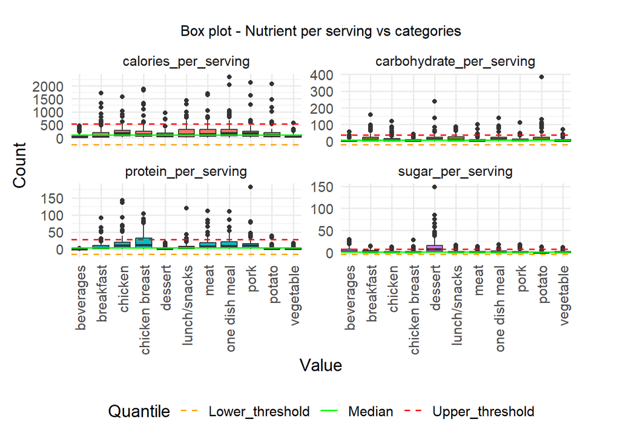

```r
# Reshape the outlier summary table for visualization, as there is no outliers in the `servings` variable
outlier_long <- outlier_table %>%
  filter(variables != "servings") %>%
  select(variables, Lower_threshold, Median, Upper_threshold) %>%
  pivot_longer(cols = c(Lower_threshold, Median, Upper_threshold),
               names_to = "Quantile",
               values_to = "Value")

# Boxplot for outlier visualization
boxplot <- recipe_imp %>%
  gather(key = "variables", value = "value", all_of(nutrient_vars_per_serving)) %>%
  ggplot(aes(x = category, y = value, fill = variables)) +
  geom_boxplot(show.legend = FALSE) +
  # Add quantile lines
  geom_hline(data = outlier_long,
             aes(yintercept = Value,
                 linetype = Quantile,
                 color = Quantile),
             linewidth = 0.7) +
  facet_wrap(~ variables, scales = "free_y") +
  scale_color_manual(values = c(Lower_threshold = "orange",
                                Median = "green",
                                Upper_threshold = "red")) +
  scale_linetype_manual(values = c(Lower_threshold = "dashed",
                                   Median = "solid",
                                   Upper_threshold = "dashed")) +
  scale_x_discrete(expand = expansion(mult = c(0, 0))) +
  labs(title = "Box plot - Nutrient per serving vs categories",
       x = "Value",
       y = "Count") +
  theme_minimal(base_size = 14) +
  theme(
      legend.position = "bottom",
      legend.box = "horizontal",
      axis.text.x = element_text(angle = 90, hjust = 1, vjust = 0.5),
      plot.title = element_text(hjust = 0.5, size = 12),
      plot.margin = ggplot2::margin(t = 20, r = 40, b = 10, l = 10))

boxplot
```

### 3.1.5 Validating the relationship between predictors and target

**Correlation matrix between numeric variables:**

**Numeric vs Categorical:**

ANOVA results show that `nutrient per serving` differ significantly across recipe categories (p < 0.05). - Servings do not differ significantly across categories (p = 0.32), indicating similar portion sizes among recipe types.

**Numeric vs Traffic:**

A t-test confirmed that `carbohydrate_per_serving` significantly differs between `Low` and `High` traffic recipes (p < 0.05), indicating its potential influence on recipe popularity. - All other numeric variables showed logical, consistent patterns without anomalies, confirming data integrity and readiness for modeling.

**Categorical vs Traffic:**

A Chi-square test was statistically significant (p = 0.000), indicating a strong association between the `high_traffic` target variable and the recipe `category`. Mean values could not be calculated due to data type, but the association remains significant.

```r
# Validating the correlation between the numeric variables
# Ensure columns are numeric
suppressWarnings(
    recipe_numeric <- recipe_imp %>%
    select(nutrient_vars_per_serving, "servings") %>%
    mutate(across(everything(), as.numeric)))
    # Compute correlation matrix
    cor_matrix <- cor(recipe_numeric, use = "pairwise.complete.obs")  # handles NAs
    # Convert to tibble with rownames
    cor_tibble <- as_tibble(cor_matrix, rownames = "Variable")

kable(cor_tibble, caption = "Correlational Matrix for numeric variables") %>%
  kable_styling(full_width = F, position = "left")
```

Correlational Matrix for numeric variables

| Variable | calories_per_serving | carbohydrate_per_serving | sugar_per_serving | protein_per_serving | servings |
| --- | --- | --- | --- | --- | --- |
| calories_per_serving | 1.0000000 | 0.1937400 | 0.0479464 | 0.3412719 | -0.4331816 |
| carbohydrate_per_serving | 0.1937400 | 1.0000000 | 0.2024344 | 0.1637578 | -0.3726752 |
| sugar_per_serving | 0.0479464 | 0.2024344 | 1.0000000 | 0.0073197 | -0.2698603 |
| protein_per_serving | 0.3412719 | 0.1637578 | 0.0073197 | 1.0000000 | -0.3481643 |
| servings | -0.4331816 | -0.3726752 | -0.2698603 | -0.3481643 | 1.0000000 |

```r
# Validating the relation between each numeric variable against Category
numeric_vars <- c(nutrient_vars_per_serving, "servings")
anova_results <- lapply(numeric_vars, function(var) {
  formula <- as.formula(paste(var, "~ category"))
  model <- aov(formula, data = recipe_imp)
  tidy(model)  # convert ANOVA output to tidy tibble
})
# Combine results into one table
names(anova_results) <- numeric_vars
anova_results_df <- bind_rows(anova_results, .id = "Variable")
# View results
anova_results_df <- anova_results_df %>%
  filter(term == "category") %>%
  mutate(significant = ifelse(p.value < 0.05, "Yes", "No"))

kable(anova_results_df, caption = "Relationship between category and numeric variables") %>%
  kable_styling(full_width = F, position = "left")
```

Relationship between category and numeric variables

| Variable | term | df | sumsq | meansq | statistic | p.value | significant |
| --- | --- | --- | --- | --- | --- | --- | --- |
| calories_per_serving | category | 10 | 4.152201e+06 | 4.152201e+05 | 5.443510 | 0.0000001 | Yes |
| carbohydrate_per_serving | category | 10 | 3.381436e+04 | 3.381436e+03 | 6.065424 | 0.0000000 | Yes |
| sugar_per_serving | category | 10 | 1.445397e+04 | 1.445397e+03 | 24.686710 | 0.0000000 | Yes |
| protein_per_serving | category | 10 | 5.371499e+04 | 5.371499e+03 | 18.703167 | 0.0000000 | Yes |
| servings | category | 10 | 3.427233e+01 | 3.427233e+00 | 1.145739 | 0.3245438 | No |

```r
# Validating the relation between numeric variables with target variable
t_test_results <- map_dfr(numeric_vars, function(var) {
  test <- t.test(recipe_imp[[var]] ~ recipe_imp$high_traffic)

  data.frame(
    variable = var,
    test_type = "t-test",
    p_value = round(test$p.value, 5),
    mean_low = round(as.numeric(test$estimate[1]), 3),
    mean_high = round(as.numeric(test$estimate[2]), 3),
    significant = ifelse(test$p.value < 0.05, "Yes", "No")
  )
})

# Validating the relation between categorical variable with target variable
table_cat <- table(recipe_imp$category, recipe_imp$high_traffic)
chi_test <- chisq.test(table_cat)

chi_results <- data.frame(
  variable = "category",
  test_type = "Chi-square",
  p_value = round(chi_test$p.value, 5),
  mean_low = NA,
  mean_high = NA,
  significant = ifelse(chi_test$p.value < 0.05, "Yes", "No")
)

relat_results <- bind_rows(t_test_results, chi_results)

kable(relat_results, caption = "Relationship between predictor and target variables") %>%
  kable_styling(full_width = F, position = "left")
```

Relationship between predictor and target variables

| variable | test_type | p_value | mean_low | mean_high | significant |
| --- | --- | --- | --- | --- | --- |
| calories_per_serving | t-test | 0.11835 | 175.686 | 203.494 | No |
| carbohydrate_per_serving | t-test | 0.04598 | 13.137 | 16.099 | Yes |
| sugar_per_serving | t-test | 0.11238 | 4.419 | 3.453 | No |
| protein_per_serving | t-test | 0.44028 | 9.965 | 10.908 | No |
| servings | t-test | 0.14448 | 3.373 | 3.540 | No |
| category | Chi-square | 0.00000 | NA | NA | Yes |

**Re-framing the dataset for better readability:**

Rearranging and renaming the variables for better readability. Removing the `recipe` variable and replacing the `nutrient per recipe` variables with the `nutrient per serving` variable in the cleaned and validated dataset for further analysis and modelling.

```r
# Realigning the dataset and variables for eda and modelling
recipe_clean <- recipe_imp %>%
    select(-nutrient_vars) %>%
    select(-recipe) %>%
    select(category, servings, calories_per_serving,
           carbohydrate_per_serving, sugar_per_serving, protein_per_serving, traffic = high_traffic)

# Checking the clean dataset
str(recipe_clean)
```

```
## tibble [947 × 7] (S3: tbl_df/tbl/data.frame)
##  $ category                : chr [1:947] "pork" "potato" "breakfast" "beverages" ...
##  $ servings                : num [1:947] 6 4 1 4 4 2 4 4 6 2 ...
##  $ calories_per_serving    : num [1:947] 241.55 8.87 914.28 24.26 6.76 ...
##  $ carbohydrate_per_serving: num [1:947] 11.39 9.64 42.68 7.64 0.46 ...
##  $ sugar_per_serving       : num [1:947] 3.02 0.16 3.09 9.66 0.2 0.82 2.44 0.1 0.56 2 ...
##  $ protein_per_serving     : num [1:947] 15.89 0.23 2.88 0 0.13 ...
##  $ traffic                 : Factor w/ 2 levels "low","high": 2 2 1 2 1 2 1 1 2 1 ...
```

```r
kable(summary(recipe_clean), caption = "Smmary statistics of the Cleaned and Validated dataset") %>%
  kable_styling(full_width = F, position = "left")
```

Smmary statistics of the Cleaned and Validated dataset

|  | category | servings | calories_per_serving | carbohydrate_per_serving | sugar_per_serving | protein_per_serving | traffic |
| --- | --- | --- | --- | --- | --- | --- | --- |
|  | Length:947 | Min. :1.000 | Min. : 0.07 | Min. : 0.01 | Min. : 0.000 | Min. : 0.00 | low :373 |
|  | Class :character | 1st Qu.:2.000 | 1st Qu.: 35.76 | 1st Qu.: 2.68 | 1st Qu.: 0.600 | 1st Qu.: 1.11 | high:574 |
|  | Mode :character | Median :4.000 | Median : 102.50 | Median : 7.68 | Median : 1.500 | Median : 3.51 | NA |
|  | NA | Mean :3.474 | Mean : 192.54 | Mean : 14.93 | Mean : 3.834 | Mean : 10.54 | NA |
|  | NA | 3rd Qu.:4.000 | 3rd Qu.: 232.85 | 3rd Qu.: 16.90 | 3rd Qu.: 3.555 | 3rd Qu.: 11.88 | NA |
|  | NA | Max. :6.000 | Max. :2332.32 | Max. :383.06 | Max. :148.750 | Max. :182.63 | NA |

### 3.1.6 Data Validation

Data Validation The dataset recipe_site_traffic_2212.csv was comprehensively assessed and cleaned to ensure analytical accuracy, completeness, and consistency for predictive modeling.

The final processed dataset, recipe_clean, includes **947 observations across 7 variables**, with all missing, duplicate, and anomalous values addressed. Importantly, **no observations were removed;** instead, all missing data were imputed logically using domain relevant methods that preserved data integrity and distribution patterns.

#### 3.1.6.1 Why Nutrient per Serving was used in the processed dataset for EDA and modelling

Normalizing nutrient per serving ensures:

- Fair comparison between recipes regardless of portion size.
- Realistic representation of how users perceive recipes (per serving, not total batch).
- Stable, interpretable inputs for machine learning models.
- Alignment with Tasty Bytes’ business goal — identifying recipes most likely to attract engagement per serving, as displayed on the homepage.

#### 3.1.6.2 Variable Validation

**`recipe` (Numeric Identifier):**

- Verified as a unique numeric identifier for each recipe, with no duplicates or missing values.
- Excluded from modelling since it does not contribute any predictive value and avoids model overfitting.

- Contains 11 predefined recipe categories: Beverages, Breakfast, Chicken, Chicken Breast, Dessert, Lunch/Snacks, Meat, One Dish Meal, Pork, Potato, Vegetable.
- This will be dummy encoded at the time of modelling. All entries are valid and complete, confirming categorical consistency.
- Ensures accurate grouping for nutrient-based imputation and analysis.

**`servings` (Numeric):**

- 3 missing values in the Lunch/Snack category were imputed using the average serving size calculated as the ratio of total nutrient content to the average nutrient per serving within the same category.
- Imputed values were rounded to realistic integer servings (1 – 6). Nutrient per serving values for these recipes were recalculated based on the imputed servings, maintaining proportionality.
- Summary statistics: Min = 1, 1st Quartile = 2, Median = 4, Mean = 3.47, 3rd Quartile = 4, Max = 6. Does not contain any outliers.

**Nutrient per serving composition (Numeric):**

- 52 missing values in the same rows were imputed using average nutrient per serving values within each recipe category, ensuring consistency with typical recipes within each category.
- Outliers detected using the IQR method were confirmed with boxplots. While high-end outliers are present, they are plausible and represent genuine variability in nutrient content across recipe categories. These values were retained to preserve realistic data patterns.
- **Summary statistics:**
  - **`calories per serving`:** 0.07 – 2332.32 kcal — light to high-calorie meals.
  - **`carbohydrate per serving:`** 0.01 – 383.06 g — spanning low-carb to carb-rich dishes.
  - **`sugar per serving:`** 0.00 – 148.75 g — typical for beverages and desserts.
  - **`protein per serving:`** 0.00 – 182.63 g — expected variation across plant- and meat-based meals.

**`traffic` (Target, Factor, 2 levels: low / high):**

- Originally incomplete; missing values were logically imputed as Low because only popular recipes were recorded as `High`, reflecting observed data collection patterns.
- Converted to a binary factor: `low` = 1, `high` = 2. Final class distribution: 60% `high`, 40% `low`, ensuring adequate representation for modelling.

#### 3.1.6.4 Final Assessment

The `recipe_clean` dataset is clean, comprehensive, and model-ready, preserving the natural diversity of Tasty Bytes’ recipes while ensuring consistent scaling and integrity.

This rigorous validation process enables:

- Reliable identification of recipe features driving high website traffic,
- Data-driven homepage optimization, and
- Actionable insights for editorial and marketing strategies.

```r
kable(head(recipe_clean), caption = "Relationship between predictor and target variables") %>%
  kable_styling(full_width = F, position = "left")
```

Relationship between predictor and target variables

| category | servings | calories_per_serving | carbohydrate_per_serving | sugar_per_serving | protein_per_serving | traffic |
| --- | --- | --- | --- | --- | --- | --- |
| pork | 6 | 241.55 | 11.39 | 3.02 | 15.89 | high |
| potato | 4 | 8.87 | 9.64 | 0.16 | 0.23 | high |
| breakfast | 1 | 914.28 | 42.68 | 3.09 | 2.88 | low |
| beverages | 4 | 24.26 | 7.64 | 9.66 | 0.00 | high |
| beverages | 4 | 6.76 | 0.46 | 0.20 | 0.13 | low |
| one dish meal | 2 | 345.58 | 1.73 | 0.82 | 26.96 | high |

## 3.2 Data Visualization

Exploratory Data Analysis (EDA) In this section, the cleaned recipe dataset is analyzed to understand patterns, distributions, and relationships among recipe attributes and traffic outcomes.

### 3.2.1 Single Variable Analysis

Single-variable plots were created to understand individual distributions:

**Distribution of Recipe Variables plots:**

**Nutrient per serving Distribution**

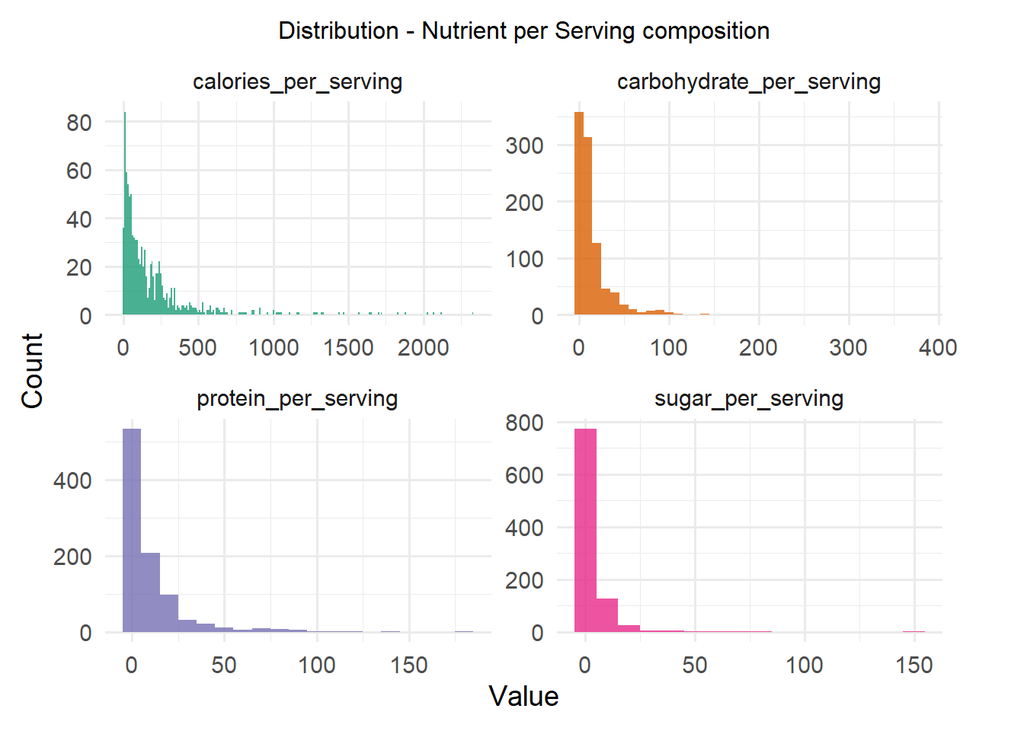

```r
# Histograms / Density Plots
# Histogram and Density plots for nutrient composition
histogram <- recipe_clean %>%
  gather(key = "nutrients", value = "value", all_of(nutrient_vars_per_serving)) %>%
  filter(value > 0) %>%
  ggplot(aes(x = value, fill = nutrients)) +
  geom_histogram(binwidth = 10, alpha = 0.8, show.legend = FALSE) +
  facet_wrap(~ nutrients, scales = "free") +
  scale_fill_brewer(palette = "Dark2") +
  labs(title = "Distribution - Nutrient per Serving composition",
     x = "Value",
     y = "Count") +
  theme_minimal(base_size = 14) +
  theme(plot.title = element_text(hjust = 0.5, size = 12),
        plot.margin = ggplot2::margin(t = 10, r = 40, b = 10, l = 10))

histogram
```

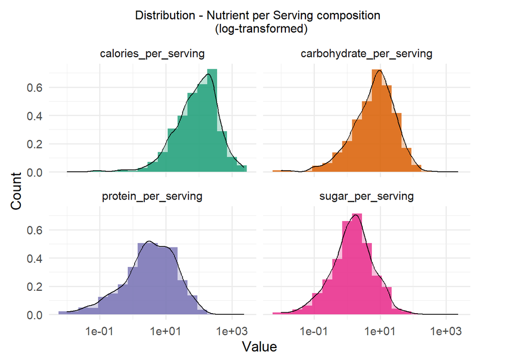

```r
histogram_log <- recipe_clean %>%
  gather(key = "nutrients", value = "value", all_of(nutrient_vars_per_serving)) %>%
  filter(value > 0) %>%
  ggplot(aes(x = value, fill = nutrients)) +
  geom_histogram(aes(y = after_stat(density)), binwidth = 0.3, alpha = 0.8, show.legend = FALSE) +
  geom_density(alpha = 0.3, show.legend = FALSE) +
  scale_x_log10() +
  facet_wrap(~ nutrients, scales = "fixed") +
  scale_fill_brewer(palette = "Dark2") +
  labs(title = paste("Distribution - Nutrient per Serving composition", "\n" ,"(log-transformed)"),
     x = "Value",
     y = "Count") +
  theme_minimal(base_size = 14) +
  theme(plot.title = element_text(hjust = 0.5, size = 12),
        plot.margin = ggplot2::margin(t = 10, r = 40, b = 10, l = 10))

histogram_log
```

**Recipe Category Frequency**

- Breakfast, Chicken Breast, and Beverages are the most frequent categories.
- All other categories have counts above 50 and occur consistently.

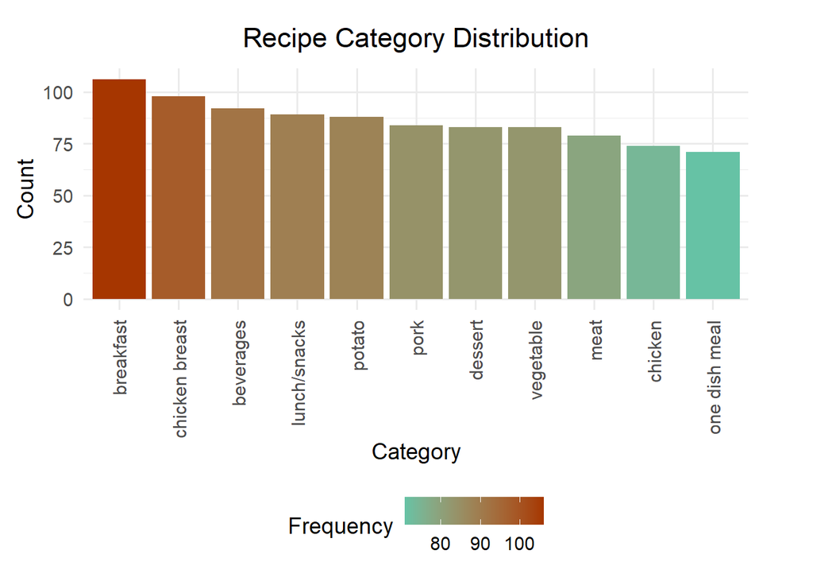

```r
# Bar plot to visualize the recipe categories frequency
bar_frequency <- recipe_clean %>%
  count(category) %>%
  arrange(desc(n)) %>%
  ggplot(aes(x = reorder(category, -n), y = n, fill = n)) +
  geom_col() +
  scale_fill_gradient(low = "#66C2A5", high = "#A63600", name = "Frequency") +
  labs(
    title = "Recipe Category Distribution",
    x = "Category",
    y = "Count"
  ) +
  theme_minimal(base_size = 14) +
  theme(
      legend.position = "bottom",
      plot.title = element_text(hjust = 0.5, vjust = 2),
      axis.text.x = element_text(angle = 90, hjust = 1, vjust = 0.5),
      plot.margin = ggplot2::margin(t = 20, r = 40, b = 10, l = 10))

bar_frequency
```

### 3.2.2 Multivariable Analysis

Multivariable Analysis Multiple variable plots were created to understand relationships between variable distributions:

**Traffic Insights**

Bar Plot / Count Plot across recipe variables Bar plots were created to visualize the distribution of the target variable (traffic) across recipe categories and serving sizes.

**Category-wise Traffic:**

- **High traffic:** Recipes in the Vegetable, Potato, and Pork categories receive the most views, indicating strong user interest.
- **Low traffic:** Beverages, Breakfast, and Chicken Breast recipes are more common in the low-traffic segment, suggesting lower user engagement for these categories.

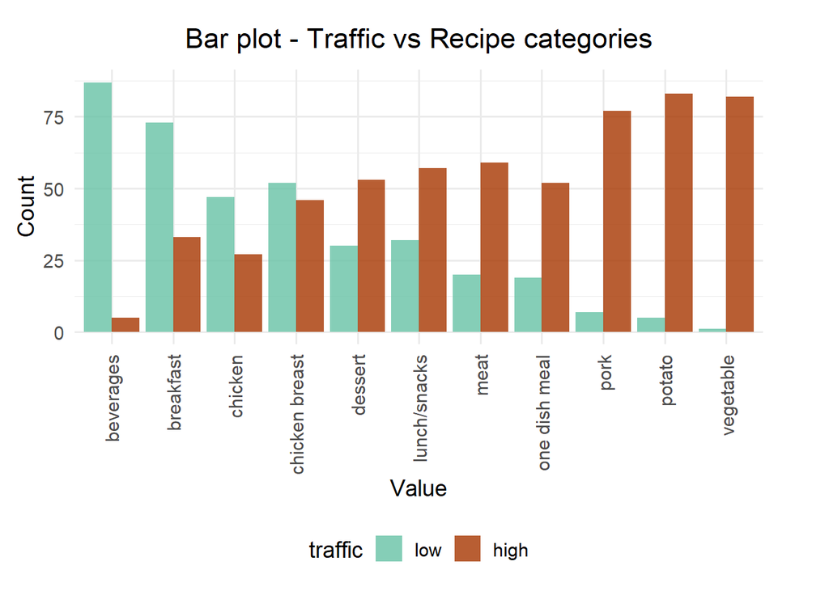

```r
# Bar plot for traffic across different categories
bar_traffic_cat <- recipe_clean %>%
  ggplot(aes(x = category, fill = traffic)) +
  geom_bar(position = "dodge", alpha = 0.8) +
  scale_fill_manual(values = c("high" = "#A63600", "low"  = "#66C2A5")) +
  labs(title = "Bar plot - Traffic vs Recipe categories",
       x = "Value",
       y = "Count") +
  theme_minimal(base_size = 14) +
  theme(
      legend.position = "bottom",
      plot.title = element_text(hjust = 0.5, vjust = 2),
      axis.text.x = element_text(angle = 90, hjust = 1, vjust = 0.5),
      plot.margin = ggplot2::margin(t = 20, r = 40, b = 10, l = 10))

bar_traffic_cat
```

**Serving Size Trends:**

- Recipes with 4 to 6 servings tend to attract higher traffic, indicating a user preference for medium to large portions.
- The 3-serving recipe appears due to imputed data used to handle missing values, so its trend should be interpreted with caution.

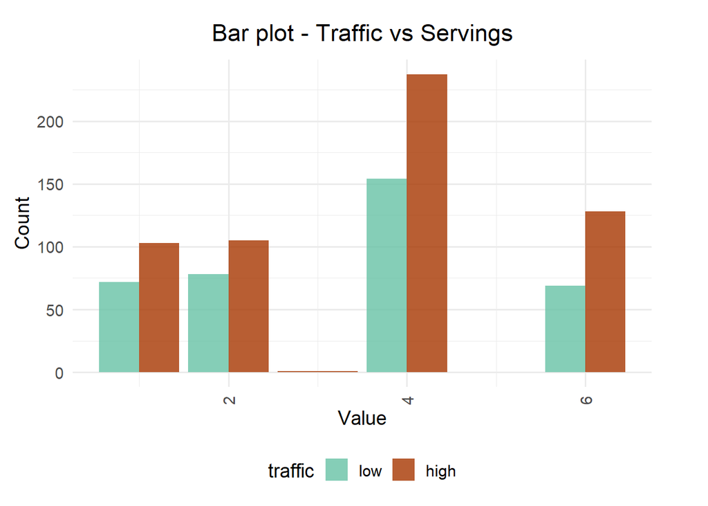

```r
# Bar plot for traffic across different servings
bar_traffic_ser <- recipe_clean %>%
  ggplot(aes(x = servings, fill = traffic)) +
  geom_bar(position = "dodge", alpha = 0.8) +
  scale_fill_manual(values = c("high" = "#A63600", "low"  = "#66C2A5")) +
  labs(title = "Bar plot - Traffic vs Servings",
       x = "Value",
       y = "Count") +
  theme_minimal(base_size = 14) +
  theme(
      legend.position = "bottom",
      plot.title = element_text(hjust = 0.5, vjust = 2),
      axis.text.x = element_text(angle = 90, hjust = 1, vjust = 0.5),
      plot.margin = ggplot2::margin(t = 20, r = 40, b = 10, l = 10))

bar_traffic_ser
```

**Histogram of Traffic vs. Nutrient Composition**

A histogram for traffic vs nutrient values revealed:

- Log transformation clarified differences between High and Low traffic recipes.
- High traffic recipes tend to have medium to high nutrient values. Users seem to prefer richer, more filling recipes.

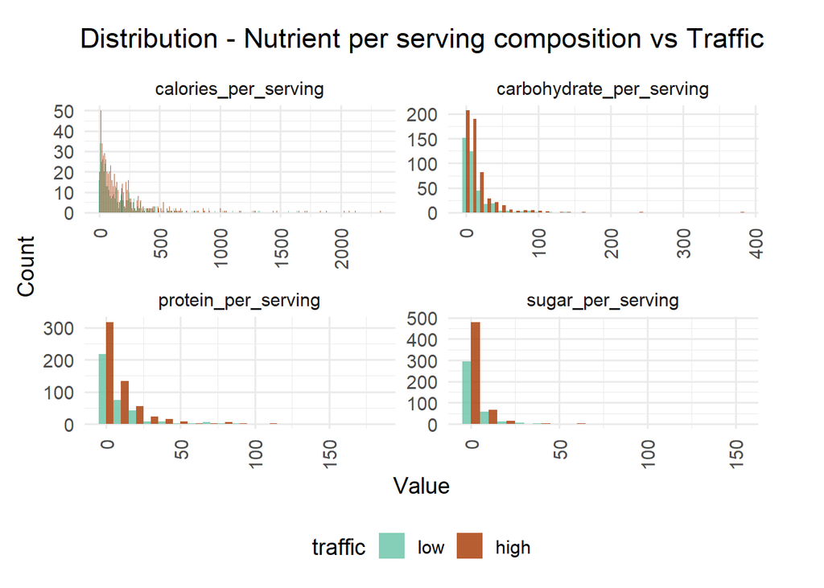

```r
# Histogram plot of traffic across nutrient composition
bar_nutrient <- recipe_clean %>%
  gather(key = "nutrients", value = "value", all_of(nutrient_vars_per_serving)) %>%
  filter(value > 0) %>%
  ggplot(aes(x = value, fill = traffic)) +
  geom_histogram(position = "dodge", binwidth = 10, alpha = 0.8) +
  facet_wrap(~ nutrients, scales = "free") +
  scale_fill_manual(values = c("high" = "#A63600", "low"  = "#66C2A5")) +
  labs(title = "Distribution - Nutrient per serving composition vs Traffic",
     x = "Value",
     y = "Count") +
  theme_minimal(base_size = 14) +
  theme(
      legend.position = "bottom",
      plot.title = element_text(hjust = 0.5, vjust = 2),
      axis.text.x = element_text(angle = 90, hjust = 1, vjust = 0.5),
      plot.margin = ggplot2::margin(t = 20, r = 40, b = 10, l = 10))

bar_nutrient
```

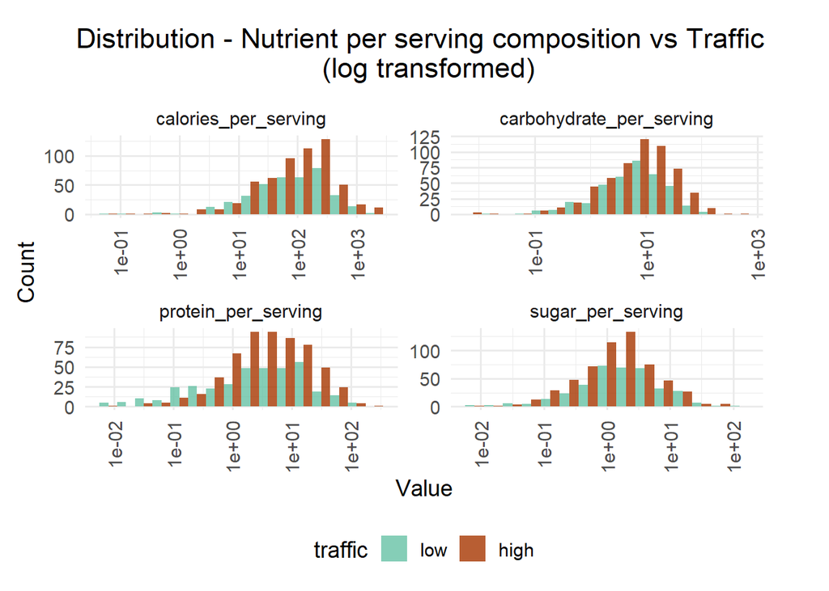

```r
bar_nutrient_log <- recipe_clean %>%
  gather(key = "nutrients", value = "value", all_of(nutrient_vars_per_serving)) %>%
  filter(value > 0) %>%
  ggplot(aes(x = value, fill = traffic)) +
  geom_histogram(position = "dodge", binwidth = 0.3, alpha = 0.8) +
  scale_x_log10() +
  facet_wrap(~ nutrients, scales = "free") +
  scale_fill_manual(values = c("high" = "#A63600", "low"  = "#66C2A5")) +
  labs(title = "Distribution - Nutrient per serving composition vs Traffic \n (log transformed)",
     x = "Value",
     y = "Count") +
  theme_minimal(base_size = 14) +
  theme(
      legend.position = "bottom",
      plot.title = element_text(hjust = 0.5, vjust = 2),
      axis.text.x = element_text(angle = 90, hjust = 1, vjust = 0.5),
      plot.margin = ggplot2::margin(t = 20, r = 40, b = 10, l = 10))

bar_nutrient_log
```

**Heatmap of Traffic by Category and Servings**

A two-dimensional heatmap was developed to examine how recipe category and serving size jointly influence website traffic.

- Recipes with 4 & 6 servings attract the most traffic, showing user preference for this portion size.
- The one 3-serving recipe in the Lunch/Snack category reflect data imputation and should be interpreted cautiously.
- **High-traffic recipes:** Vegetable, Potato, and Pork categories at 4 servings.
- **Low-traffic recipes:** Breakfast, Beverages, and Chicken Breast at 4 servings.

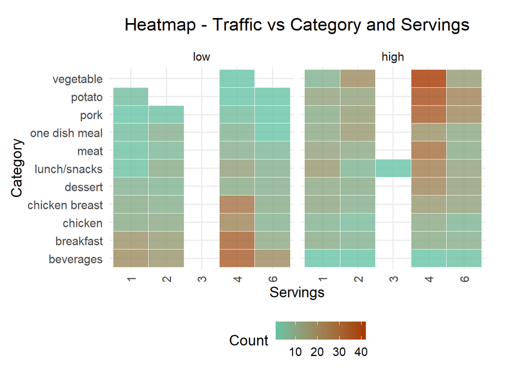

```r
# Heatmap of Traffic by Category and Servings
hm_traffic_ser <- recipe_clean %>%
  group_by(category, servings, traffic) %>%
  summarise(count = n(), .groups = "drop") %>%
  ggplot(aes(x = as.factor(servings), y = category, fill = count)) +
  geom_tile(color = "white", alpha = 0.8) +
  facet_wrap(~traffic) +
  scale_fill_gradient(low = "#66C2A5", high = "#A63600") +
  labs(title = "Heatmap - Traffic vs Category and Servings",
       x = "Servings", y = "Category", fill = "Count") +
  theme_minimal(base_size = 14) +
  theme(
      legend.position = "bottom",
      plot.title = element_text(hjust = 0.5, vjust = 2),
      axis.text.x = element_text(angle = 90, hjust = 1, vjust = 0.5),
      plot.margin = ggplot2::margin(t = 20, r = 40, b = 10, l = 10))

hm_traffic_ser
```

**Feature Relationships**

**Correlation Heatmap**

A correlation heatmap was generated for the numeric variables in the dataset.

- Numeric variables show no strong correlations, each providing unique information.
- All can be kept in the model without multicollinearity concerns.

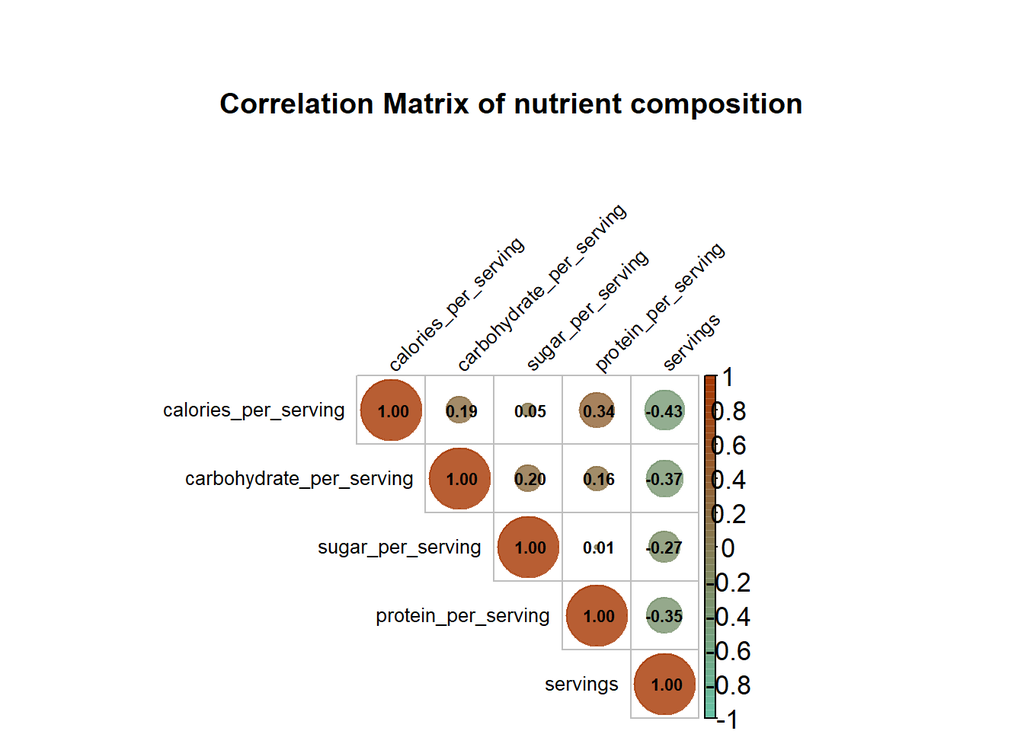

```r
# Correlation Matrix for the soil parameters
cor_matrix <- cor(recipe_clean %>% select(all_of(c(nutrient_vars_per_serving, "servings"))))
suppressWarnings(corrplot(cor_matrix, method = "circle", type = "upper",
         tl.col = "black", tl.srt = 45, tl.cex = 0.8, cl.cex = 1.1,
         col = adjustcolor(colorRampPalette(c("#66C2A5", "#A63600"))(200),
                           alpha.f = 0.8),
         addCoef.col = "black", number.cex = 0.7, number.digits = 2,
         title = "Correlation Matrix of nutrient composition",
         insig = "blank", cl.lim = c(-1, 1), mar = c(0,0,7,0)))
```

### 3.2.3 Overall Summary of EDA

The exploratory data analysis of the recipe dataset provides key insights that directly support Tasty Bytes’ goal of predicting and featuring recipes that drive `High` website traffic.

**Nutrient per serving Composition and Outliers**

Nutrient per serving variations are normally distributed after log transformation. Nutrient per serving Outlier values across categories align with real-world recipe types.

**Traffic Patterns by Category and Serving Size**

**Nutrient Intensity and User Engagement**

Density plots and histograms reveal that recipes with higher nutrient content tend to attract more traffic. This suggests users prefer substantial, satisfying recipes over lighter options when browsing featured recipes.

**Feature Relationships and Multicollinearity**

Correlation analysis shows no strong linear dependencies among numeric variables, meaning each contributes distinct predictive value. This ensures the model can leverage diverse recipe attributes without redundancy.

**Overall Insight:**

Both nutrient composition and recipe characteristics (category and serving size) significantly influence user engagement. Recipes that are rich in nutrients, moderately portioned, and belong to popular categories are more likely to drive `High` traffic. These findings align directly with Tasty Bytes’ business goal — to use data-driven insights for smarter homepage recipe selection that maximizes visibility, engagement, and subscriptions.

# 4 Machine Learning Models

The exploratory data analysis (EDA) and data visualizations revealed that nutrient composition, recipe category, and serving size all influence recipe traffic. This is a classification problem — predicting whether a recipe belongs to the `High` or `Low` traffic group based on its features.

## 4.1 Functions for Model Metric and Evaluation

The machine learning models were trained on the **training dataset** and evaluated using the **testing dataset** to predict whether a recipe generates **`High`** or **`Low`** traffic. To ensure consistent and efficient evaluation across models and business goals, reusable functions were developed for:

**Confusion Matrix:**  
Summarizes correct vs. incorrect predictions for `Low` and `High` traffic recipes.

```r
# Functions to plot confusion matrix
plot_cm <- function(cm, model_name) {
    cm_df <- as.data.frame(cm$table)
    colnames(cm_df) <- c("Prediction", "Reference", "Frequency")
    cm_df$Model <- model_name
    return(cm_df)
}
```

**Model Metrics Dataframe:**

Consolidates key performance metrics - `Accuracy, Precision, Recall, F1-score and ROC-AUC` - for each model, enabling easy straightforward comparison involving both the traffic factors - `High & Low`.

- **Accuracy:** Overall proportion of correct predictions.
- **Precision:** How many predicted positives are actually positive.
- **Sensitivity (Recall):** How well the model detects actual positives.
- **Specificity:** How well the model detects actual negatives.
- **F1 Score:** Balance between precision and recall.
- **ROC AUC:** Overall ability to distinguish between classes.

```r
# Function to get metrics for the model
get_metrics <- function(cm, auc_val, model_name = "Model"){
  accuracy <- as.numeric(cm$overall["Accuracy"])
  sensitivity <- as.numeric(cm$byClass["Sensitivity"])
  specificity <- as.numeric(cm$byClass["Specificity"])
  precision <- as.numeric(cm$byClass["Pos Pred Value"])
  if(!is.na(precision) & !is.na(sensitivity)){
    f1 <- 2 * ((precision * sensitivity) / (precision + sensitivity))
  } else {
    f1 <- NA
  }
  # Return as a dataframe
  df <- tibble(
    Model = model_name,
    Accuracy = accuracy,
    Precision = precision,
    `Sensitivity/Recall` = sensitivity,
    Specificity = specificity,
    F1_score = f1,
    ROC_AUC = as.numeric(auc_val))

  return(df)
}
```

**Variable Importance plots:**

Highlights the most influential recipe features driving traffic predictions.

```r
plot_all_varimp <- function(models, model_names) {

  varimps <- lapply(seq_along(models), function(i) {
    vi <- varImp(models[[i]], scale = TRUE)$importance
    vi <- vi %>%
      tibble::rownames_to_column("Variable") %>%
      mutate(Model = model_names[i])

    # Handle binary classification outputs (Low/High)
    if (all(c("low", "high") %in% colnames(vi))) {
      vi <- vi %>%
        mutate(Importance = pmax(low, high)) %>%
        select(Variable, Importance, Model)

    } else if ("Overall" %in% colnames(vi)) {
      vi <- vi %>%
        rename(Importance = Overall) %>%
        select(Variable, Importance, Model)

    } else {
      stop("The model's varImp output has unexpected column names.")
    }

    # Scale within model to [0,100]
    vi <- vi %>%
      mutate(Importance = 100 * Importance / max(Importance, na.rm = TRUE))

    return(vi)
  })

  varimp_df <- bind_rows(varimps)
  return(varimp_df)
}
```

**ROC-AUC Plots:**

Visualizes the trade-offs between sensitivity and specificity while computing the Area Under the Curve (AUC).

```r
# Function to plot ROC with AUC and highlighted threshold point
roc_to_df <- function(roc_obj, model_name = "Model") {
  # Full ROC curve
  roc_df <- data.frame(
    FPR = 1 - roc_obj$specificities,
    TPR = roc_obj$sensitivities,
    Model = model_name)
  # Best threshold using Youden's index
  opt <- coords(roc_obj, "best",
    ret = c("specificity", "sensitivity"),
    best.method = "youden")
  opt <- as.numeric(opt)  # ensure numeric
  # Threshold point dataframe with correct column names
  point_df <- data.frame(
    FPR = 1 - opt[1],  # 1 - specificity
    TPR = opt[2],      # sensitivity
    Model = model_name)
  # Compute AUC
  auc_val <- as.numeric(auc(roc_obj))
  # Add auc_val column to roc_df
  roc_df$AUC <- auc_val
  point_df$AUC <- auc_val
  # Return all
  return(list(
    roc_df = roc_df,
    point_df = point_df,
    auc = auc_val
  ))
}
```

**Business KPIs for all the models:**

To align model evaluation with business objectives, defined a business-relevant KPIs. This directly measures the predictions only on the High traffic recipes and how well a model supports the company’s business goals of correctly predicting High traffic recipes 80% of the time.

**Formulas for Model Performance Metrics:**

- **`Recall High Traffic (%):`** Measures how effectively the model identifies recipes that actually receive high traffic.

  `RecallHigh Traffic(%) = (True High-traffic Predictions / Total Actual High-Traffic Predictions) * 100`
- **`Overall Accuracy High Traffic (%):`** Represents the percentage of total correct predictions (both high and low traffic).

  `Overall AccuracyHigh Traffic(%) = ((True High-Traffic + True Low-Traffic) / Total Predictions) * 100`
- **`F1 Score High Traffic :`** The harmonic mean of precision and recall for high-traffic recipes, balancing false positives and false negatives.

  `F1 ScoreHigh Traffic= 2 * ((Precision High Traffic * Recall High Traffic) / (Precision High Traffic + Recall High Traffic))`

  where,

  `PrecisionHigh Traffic` `= True-High Traffic / Predicted-High Traffic`

  `RecallHigh Traffic` `= True-High Traffic / Actual-High Traffic`

```r
# Enhanced function to compute multiple KPIs for all models
compute_business_metrics <- function(predictions_list, true_labels, positive_class = "high") {
  kpi_results <- data.frame(
    Model = character(),
    Recall_High_Traffic = numeric(),
    Accuracy = numeric(),
    F1_High_Traffic = numeric(),
    stringsAsFactors = FALSE
  )

  for(modelname in names(predictions_list)) {
    preds <- predictions_list[[modelname]]
    # Ensure factor levels match
    preds <- factor(preds, levels = levels(true_labels))
    # Accuracy
    accuracy <- mean(preds == true_labels) * 100
    # High traffic Recall
    high_correct <- sum(preds == positive_class & true_labels == positive_class)
    total_high <- sum(true_labels == positive_class)
    kpi_high <- (high_correct / total_high) * 100
    # F1-score for High traffic
    precision <- ifelse(sum(preds == positive_class) == 0, 0,
                        sum(preds == positive_class & true_labels == positive_class) /
                        sum(preds == positive_class))
    recall <- ifelse(total_high == 0, 0,
                     sum(preds == positive_class & true_labels == positive_class) /
                     total_high)
    f1_high <- ifelse((precision + recall) == 0, 0,
                      2 * (precision * recall) / (precision + recall))

    # Append to results
    kpi_results <- rbind(kpi_results,
                         data.frame(Model = modelname,
                                    Accuracy = round(accuracy, 2),
                                    Recall_High_Traffic = round(kpi_high, 2),
                                    F1_High_Traffic = round(f1_high, 2)))
  }

  return(kpi_results)
}
```

## 4.2 Model Selection

Model Selection To balance interpretability and performance, the following models were selected:

- **Logistic Regression:** Serves as a *baseline model* to capture linear relationships between recipe features and traffic.
- **Decision Trees:** Designed to model non-linear relationships and feature interactions.
- **Random Forest:** An ensemble approach that improves predictive accuracy while identifying important predictors.
- **Gradient Boosted Trees (XGBoost):** A boosting-based classification method focused on minimizing misclassifications and enhancing model performance.

These models allow us to compare simple, interpretable models and complex algorithms to balance accuracy and interpretability.

## 4.3 Data Split and Model Training

Steps included:

- Splitting data (70% train / 30% test)
- Dummy encoding categorical variables
- Normalization (centering and scaling)
- Model training using caret framework

The final cleaned dataset was prepared accordingly to support machine learning workflows and predictive modelling. Each model was fitted on the training data and evaluated on the test dataset using consistent preprocessing.

```r
# Set seed for reproducibility
set.seed(123)

# Split into training and test datasets
train_index <- createDataPartition(recipe_clean$traffic, p = 0.7, list = FALSE)
train <- recipe_clean[train_index, ]
test <- recipe_clean[-train_index, ]

# Dummy encoding for categorical variables
dummies <- dummyVars(traffic ~., data = train)
train_dummy <- predict(dummies, newdata = train)
test_dummy <- predict(dummies, newdata = test)

# Add back target column
train_proc <- data.frame(train_dummy, traffic = train$traffic)
test_proc <- data.frame(test_dummy, traffic = test$traffic)

# PreProcessing the recipe_clean dataset for normalization across models
preProc <- preProcess(train, method = c('center', 'scale'))
train_final <- predict(preProc, train_proc)
test_final <- predict(preProc, test_proc)

# True labels
true_labels <- test_final$traffic

str(train_final)
```

```
## 'data.frame':    664 obs. of  17 variables:
##  $ categorybeverages       : num  0 0 1 0 0 0 0 0 0 0 ...
##  $ categorybreakfast       : num  0 1 0 0 0 0 1 0 0 0 ...
##  $ categorychicken         : num  0 0 0 0 0 1 0 0 0 0 ...
##  $ categorychicken.breast  : num  0 0 0 0 0 0 0 0 0 0 ...
##  $ categorydessert         : num  0 0 0 0 0 0 0 0 0 0 ...
##  $ categorylunch.snacks    : num  0 0 0 0 1 0 0 0 0 0 ...
##  $ categorymeat            : num  0 0 0 0 0 0 0 0 0 1 ...
##  $ categoryone.dish.meal   : num  0 0 0 1 0 0 0 0 0 0 ...
##  $ categorypork            : num  0 0 0 0 0 0 0 0 0 0 ...
##  $ categorypotato          : num  1 0 0 0 0 0 0 1 0 0 ...
##  $ categoryvegetable       : num  0 0 0 0 0 0 0 0 1 0 ...
##  $ servings                : num  0.326 -1.424 0.326 -0.84 0.326 ...
##  $ calories_per_serving    : num  -0.661 2.677 -0.669 0.58 -0.418 ...
##  $ carbohydrate_per_serving: num  -0.219 1.027 -0.564 -0.517 -0.552 ...
##  $ sugar_per_serving       : num  -0.4151 -0.0902 -0.4107 -0.342 -0.4218 ...
##  $ protein_per_serving     : num  -0.566 -0.426 -0.572 0.851 -0.149 ...
##  $ traffic                 : Factor w/ 2 levels "low","high": 2 1 1 2 1 1 1 2 2 2 ...
```

```r
str(test_final)
```

```
## 'data.frame':    283 obs. of  17 variables:
##  $ categorybeverages       : num  0 1 0 0 1 0 0 0 0 0 ...
##  $ categorybreakfast       : num  0 0 0 0 0 0 0 0 0 1 ...
##  $ categorychicken         : num  0 0 0 0 0 0 0 1 0 0 ...
##  $ categorychicken.breast  : num  0 0 1 0 0 0 0 0 0 0 ...
##  $ categorydessert         : num  0 0 0 0 0 0 0 0 0 0 ...
##  $ categorylunch.snacks    : num  0 0 0 0 0 0 0 0 0 0 ...
##  $ categorymeat            : num  0 0 0 0 0 1 1 0 0 0 ...
##  $ categoryone.dish.meal   : num  0 0 0 0 0 0 0 0 0 0 ...
##  $ categorypork            : num  1 0 0 1 0 0 0 0 0 0 ...
##  $ categorypotato          : num  0 0 0 0 0 0 0 0 1 0 ...
##  $ categoryvegetable       : num  0 0 0 0 0 0 0 0 0 0 ...
##  $ servings                : num  1.492 0.326 0.326 1.492 -1.424 ...
##  $ calories_per_serving    : num  0.1966 -0.6044 -0.5243 -0.3629 -0.0667 ...
##  $ carbohydrate_per_serving: num  -0.1526 -0.2939 -0.13 -0.5581 0.0826 ...
##  $ sugar_per_serving       : num  -0.098 0.6383 -0.1623 -0.3708 0.0218 ...
##  $ protein_per_serving     : num  0.2638 -0.5785 0.0406 -0.5451 -0.5302 ...
##  $ traffic                 : Factor w/ 2 levels "low","high": 2 2 1 2 1 2 2 1 2 2 ...
```

## 4.4 Model Fitting

### 4.4.1 Logistic Regression (Baseline Model)

Logistic Regression served as the baseline model to predict High traffic using nutrient composition, servings, and recipe category. Coefficients offer clear insights into features that increase or decrease traffic.

Logistic Coefficient plots,

- **Recipe Categories:**
  - Vegetables, Potato, and Pork categories strongly boost website `High` traffic.
  - Beverages, Breakfast, and Chicken/Chicken Breast show `Low` traffic likelihood.
- **Nutrient Composition** and **Servings** have a smaller positive effect on traffic.

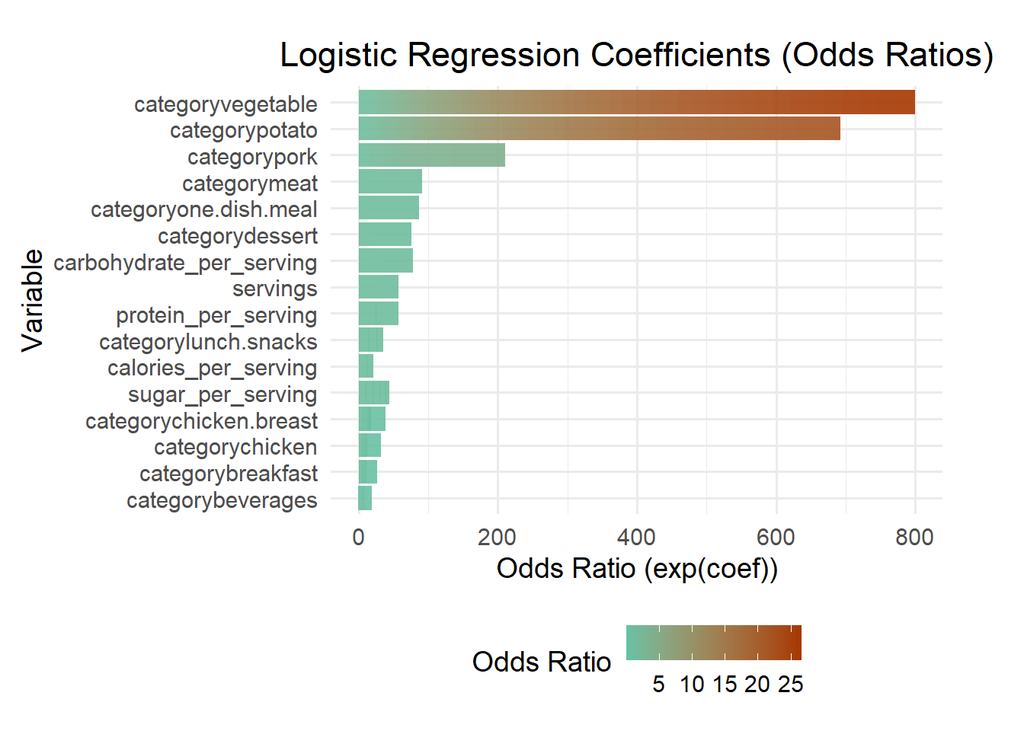

```r
# Building the logistic regression model
log_model <- train(traffic ~ . + 0, data = train_final,
                   method = 'glmnet', family = "binomial",
                   trControl = trainControl(method = 'cv',
                              number = 5))

# Extract coefficients and odds ratios
log_coef <- broom::tidy(log_model$finalModel) %>%
  mutate(OddsRatio = exp(estimate)) %>%
  filter(term != "(Intercept)")

# Plot with Dark2 colors, filled by odds ratio value
ggplot(log_coef, aes(x = reorder(term, OddsRatio),
                     y = OddsRatio,
                     fill = OddsRatio)) +
  geom_col(alpha = 0.9) +
  coord_flip() +
  scale_fill_gradient(low = "#66C2A5", high = "#A63600") +
  theme_minimal(base_size = 14) +
  labs(title = "Logistic Regression Coefficients (Odds Ratios)",
       x = "Variable",
       y = "Odds Ratio (exp(coef))",
       fill = "Odds Ratio") +
  theme(
      legend.position = "bottom",
      plot.title = element_text(hjust = 0.5, vjust = 1),
      axis.text.x = element_text(hjust = 0.5),
      plot.margin = ggplot2::margin(t = 20, r = 40, b = 10, l = 10))
```

```r
# Predict the target variable using the test data
log_preds <- predict(log_model, test_final)
log_probs <- predict(log_model, test_final, type = "prob")[, "high"]

# ROC dataframe
roc_log <- roc(true_labels, log_probs)
roc_log <- roc_to_df(roc_log, "Logistic Regression")

# Construct the confusion matrix
log_cm <- caret::confusionMatrix(log_preds, test_final$traffic)
plot_log <- plot_cm(log_cm, "Logistic Regression")

# Logistic regression model results
log_results <- get_metrics(log_cm, roc_log$auc, "Logistic Regression")

# Print the results
kable(log_results, caption = "Logistic Regression Model Results") %>%
  kable_styling(full_width = F, position = "left")
```

Logistic Regression Model Results

| Model | Accuracy | Precision | Sensitivity/Recall | Specificity | F1_score | ROC_AUC |
| --- | --- | --- | --- | --- | --- | --- |
| Logistic Regression | 0.745583 | 0.7010309 | 0.6126126 | 0.8313953 | 0.6538462 | 0.802797 |

### 4.4.2 Decision Tree

The Decision Tree model captures **non-linear relationships and feature interactions** to identify which recipe attributes—such as category, servings, and nutrient composition—drive user traffic on Tasty Bytes. The Decision Tree achieved **71.7% accuracy** and **ROC AUC 0.686**.

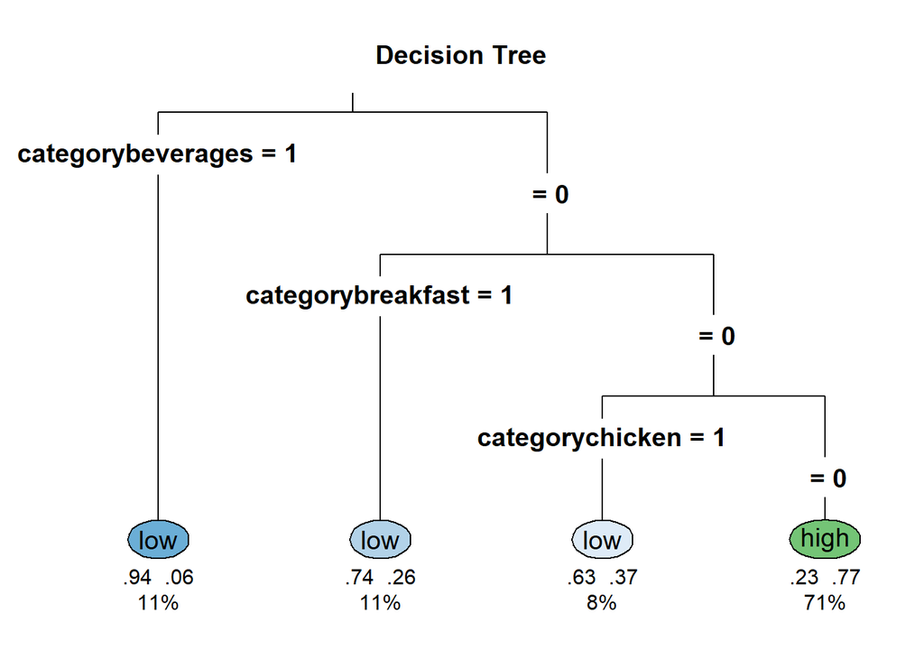

```r
# Building the logistic regression model
dt_model <- train(traffic ~ .,
                  data = train_final,
                  method = 'rpart',
                  trControl = trainControl(
                    method = 'cv',
                    number = 5),
                  tuneLength = 10)

# Plot the tree
rpart.plot(dt_model$finalModel, type = 3,
           extra = 104, under = TRUE, tweak = 1.2,
           fallen.leaves = TRUE, main = "Decision Tree")
```

```r
# Predict the target variable using the test data
dt_preds <- predict(dt_model, test_final)
dt_probs <- predict(dt_model, test_final, type = "prob")[, "high"]

# ROC dataframe
roc_dt <- roc(true_labels, dt_probs)
roc_dt <- roc_to_df(roc_dt, "Decision Tree")

# Construct the confusion matrix
dt_cm <- caret::confusionMatrix(dt_preds, test_final$traffic)
plot_dt <- plot_cm(dt_cm, "Decision Tree")

# Logistic regression model results
dt_results <- get_metrics(dt_cm, roc_dt$auc, "Decision Tree")

# Print the results
kable(dt_results, caption = "Decision Tree Model Results") %>%
  kable_styling(full_width = F, position = "left")
```

Decision Tree Model Results

| Model | Accuracy | Precision | Sensitivity/Recall | Specificity | F1_score | ROC_AUC |
| --- | --- | --- | --- | --- | --- | --- |
| Decision Tree | 0.7173145 | 0.7012987 | 0.4864865 | 0.8662791 | 0.5744681 | 0.6858894 |

### 4.4.3 Random Forest

Random Forest uses an ensemble of trees to model non-linear relationships and feature interactions, improving accuracy.

- Tree plot shows recipe category as the top predictor;
- Beverages indicate Low traffic, while other splits highlight traffic categories and portion sizes.

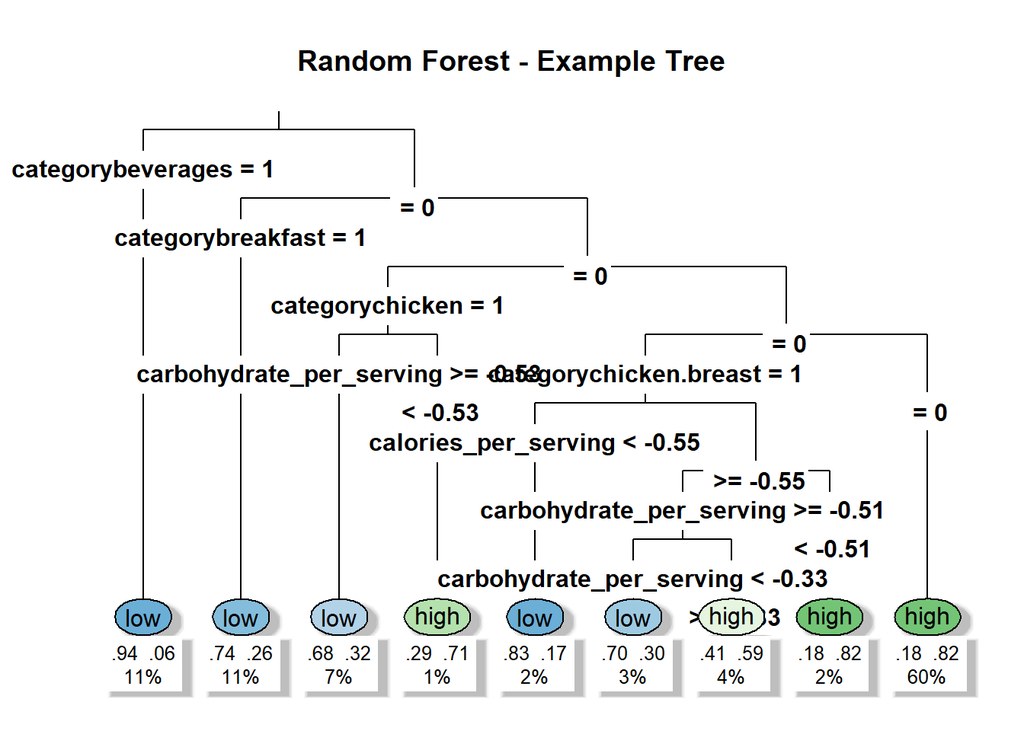

```r
# Building the random forest model
rf_model <- train(traffic ~ ., data = train_final,
                  method = 'rf',
                  trControl = trainControl(
                    method = 'cv',
                    number = 5),
                  importance = TRUE)

# Plot with full customization
tree_rpart <- rpart(traffic ~ ., data = train_final, method = "class")

rpart.plot(tree_rpart, type = 3,
           extra = 104, fallen.leaves = TRUE,
           cex = 1, border.col = "black", shadow.col = "gray",
           under = TRUE, branch.lty = 1,
           main = "Random Forest - Example Tree")
```

```r
# Predict the target variable using the test data
rf_preds <- predict(rf_model, test_final)
rf_probs <- predict(rf_model, test_final, type = "prob")[, "high"]

# ROC dataframe
roc_rf <- roc(true_labels, rf_probs)
roc_rf <- roc_to_df(roc_rf, "Random Forest")

# Construct the confusion matrix
rf_cm <- caret::confusionMatrix(rf_preds, test_final$traffic)

# Plotting the confusion matrix
plot_rf <- plot_cm(rf_cm, "Random Forest")

# Random forest model results
rf_results <- get_metrics(rf_cm, roc_rf$auc, "Random Forest")

# Print the results
kable(rf_results, caption = "Random Forest Model Results") %>%
  kable_styling(full_width = F, position = "left")
```

Random Forest Model Results

| Model | Accuracy | Precision | Sensitivity/Recall | Specificity | F1_score | ROC_AUC |
| --- | --- | --- | --- | --- | --- | --- |
| Random Forest | 0.7102473 | 0.6835443 | 0.4864865 | 0.8546512 | 0.5684211 | 0.7786769 |

### 4.4.4 XGB Boost

XGBoost is a **boosting-based ensemble model** that captures complex interactions between recipe features, enabling accurate prediction of high-traffic recipes. It helps optimize homepage selection by identifying recipes most likely to engage users. The XGB Boost model achieved **72.1% accuracy** and **ROC AUC 0.788**, with **precision 70.5%** and **sensitivity 49.5%**. **Recipe category** (starting with Beverages) is the main predictor of traffic, while **servings and nutrient composition** provide additional predictive value.

```r
# Building the logistic regression model
xgb_model <- train(traffic ~ ., data = train_final, method = "xgbTree",
                   trControl = trainControl(method = "cv", number = 5),
                   tuneGrid = expand.grid(
                     nrounds = 50, max_depth = 3,
                     eta = 0.1, gamma = 0,
                     colsample_bytree = 1, min_child_weight = 1, subsample = 1)
)

# Plot the tree
xgb.plot.tree(model = xgb_model$finalModel, trees = 3,
              show_node_id = TRUE, render = TRUE)
```

[interactive chart not shown]

```r
# Predict the target variable using the test data
xgb_preds <- predict(xgb_model, test_final)
xgb_probs <- predict(xgb_model, test_final, type = "prob")[, "high"]

# ROC dataframe
roc_xgb <- roc(true_labels, xgb_probs)
roc_xgb <- roc_to_df(roc_xgb, "XGBoost")

# Construct the confusion matrix
xgb_cm <- caret::confusionMatrix(xgb_preds, test_final$traffic)

# Plotting the confusion matrix
plot_xgb <- plot_cm(xgb_cm, "XGBoost")

# Logistic regression model results
xgb_results <- get_metrics(xgb_cm, roc_xgb$auc, "XGBoost")

# Print the results
kable(xgb_results, caption = "XGBoost Model Results") %>%
  kable_styling(full_width = F, position = "left")
```

XGBoost Model Results

| Model | Accuracy | Precision | Sensitivity/Recall | Specificity | F1_score | ROC_AUC |
| --- | --- | --- | --- | --- | --- | --- |
| XGBoost | 0.7208481 | 0.7051282 | 0.4954955 | 0.8662791 | 0.5820106 | 0.7884192 |

# 5 Model Results & Evaluation

The machine learning models were evaluated using confusion matrices, performance metrics, feature importance, and ROC-AUC curves to compare their ability to predict High vs Low recipe traffic.

## 5.1 Confusion Matrix & Model Metrics Comparison

Confusion matrices highlight each model’s ability to correctly classify both High and Low traffic recipes:

**Model Performance Summary:**

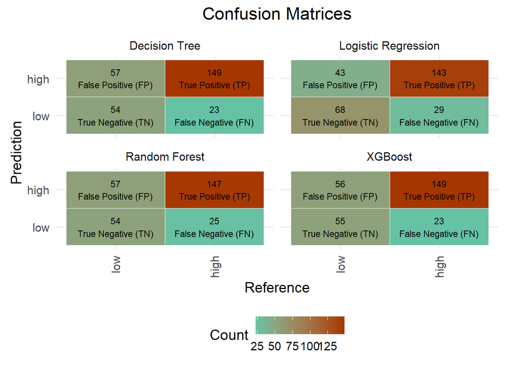

```r
# Combine all confusion matrices
all_cm <- bind_rows(plot_log, plot_dt, plot_rf, plot_xgb)

# Convert Prediction & Reference to factors with consistent levels
levels_order <- c("low", "high")
all_cm <- all_cm %>%
  mutate(
    Prediction = factor(Prediction, levels = levels_order),
    Reference = factor(Reference, levels = levels_order)
  ) %>%
  mutate(Label = case_when(
    Prediction == "high" & Reference == "high" ~ "True Positive (TP)",
    Prediction == "high" & Reference == "low"  ~ "False Positive (FP)",
    Prediction == "low"  & Reference == "low"  ~ "True Negative (TN)",
    Prediction == "low"  & Reference == "high" ~ "False Negative (FN)",
    TRUE ~ ""
  ))

# Plot confusion matrices with labels
all_cm_plot <- ggplot(all_cm, aes(x = Reference, y = Prediction, fill = Frequency)) +
  geom_tile(color = "white") +
  geom_text(aes(label = paste0(Frequency, "\n", Label)), color = "black", size = 3) +
  scale_fill_gradient(low = "#66C2A5", high = "#A63600") +
  theme_minimal(base_size= 14) +
  facet_wrap(~Model, ncol = 2, scales = "fixed") +
  labs(title = "Confusion Matrices", fill = "Count") +
  theme(
      legend.position = "bottom",
      plot.title = element_text(hjust = 0.5, vjust = 2),
      axis.text.x = element_text(angle = 90, hjust = 1, vjust = 0.5),
      plot.margin = ggplot2::margin(t = 10, r = 20, b = 10, l = 10))

all_cm_plot
```

```r
# Creating the model metric data frame
combined_results <- bind_rows(log_results, dt_results, rf_results, xgb_results)

# Transposing the combined results dataframe
model_results <- combined_results %>%
  select(-Model) %>%
  t() %>%
  as.data.frame() %>%
  rownames_to_column(var = "Metric")

# Round only numeric columns
model_results[, -1] <- round(model_results[, -1], 3)
colnames(model_results)[-1] <- combined_results$Model

# Data frame to compare all the model results for comparison
kable(model_results, caption = "Model Results") %>%
  kable_styling(full_width = F, position = "left")
```

Model Results

| Metric | Logistic Regression | Decision Tree | Random Forest | XGBoost |
| --- | --- | --- | --- | --- |
| Accuracy | 0.746 | 0.717 | 0.710 | 0.721 |
| Precision | 0.701 | 0.701 | 0.684 | 0.705 |
| Sensitivity/Recall | 0.613 | 0.486 | 0.486 | 0.495 |
| Specificity | 0.831 | 0.866 | 0.855 | 0.866 |
| F1_score | 0.654 | 0.574 | 0.568 | 0.582 |
| ROC_AUC | 0.803 | 0.686 | 0.779 | 0.788 |

## 5.2 Variable Importance Plots

The scaled variable importance plot compares how Logistic Regression and Random Forest evaluates the influence of recipe features on predicting High vs. Low traffic:

**Recipe Category:**

The dominant predictor for traffic in the models, consistent with EDA findings.

- **High traffic:** Vegetables, Potato and Pork.
- **Low traffic:** Beverages, Breakfast, and Chicken.

**Nutrient Composition:**

Secondary influence. Protein: Some importance in Random Forest. Carbohydrates, Calories, Sugar: Relatively low impact.

**Servings:**

Minimal importance, confirming limited effect on traffic compared to category and nutrients. Consistency Across Models:

Overall, the variable importance plots show a consistent pattern where category-related features hold the highest influence for predictions, while nutrient-based variables also contribute notably to model predictions, though with varying degrees of importance.

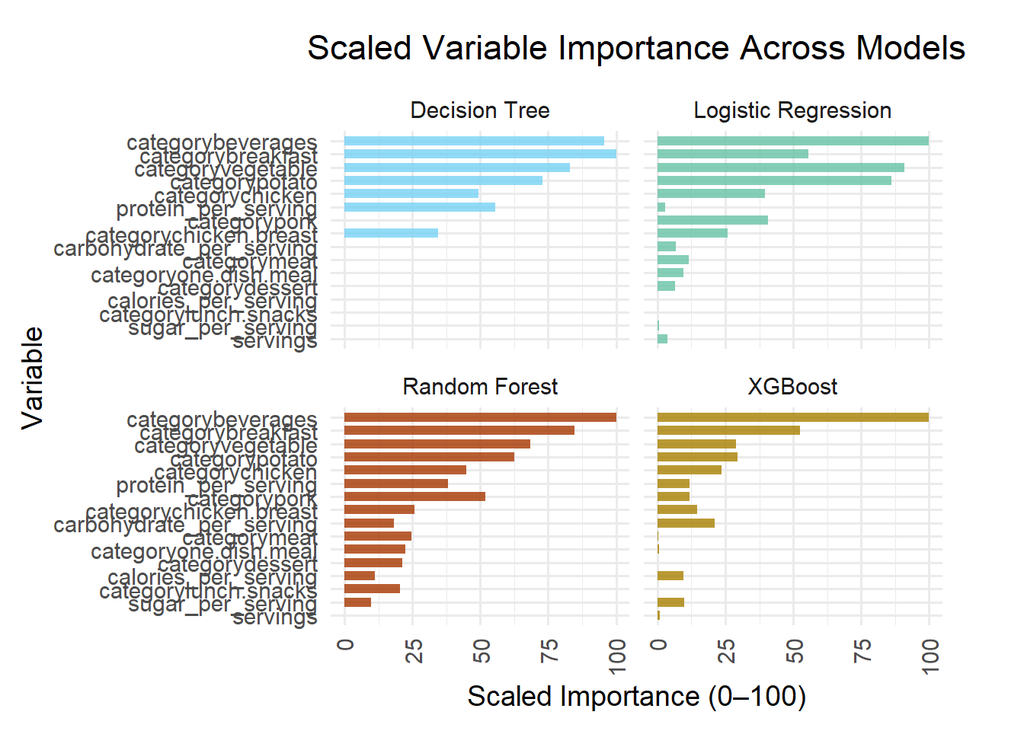

```r
# Creating data frame to plot all the variable importance
varimp_df <- plot_all_varimp(
  models = list(log_model, dt_model, rf_model, xgb_model),
  model_names = c("Logistic Regression",
                  "Decision Tree",
                  "Random Forest",
                  "XGBoost"))

# Apply the variable importance function
ggplot(varimp_df, aes(x = reorder(Variable, Importance),
                      y = Importance,
                      fill = Model)) +
  geom_col(position = position_dodge(width = 0.9),
           width = 0.7, alpha = 0.8, show.legend = FALSE) +
  coord_flip() +
  scale_x_discrete(expand = expansion(mult = c(0.05, 0.05))) +
  scale_fill_manual(values = c("Logistic Regression" = "#66C2A5",
                               "Decision Tree" = "#77D2F5",
                               "Random Forest" = "#A63600",
                               "XGBoost" = "#A78000")) +
  facet_wrap(~ Model, scales = "fixed") +
  theme_minimal(base_size = 14) +
  theme(
    axis.text.y  = element_text(size = 10, hjust = 1,face = "bold"),
    axis.text.x  = element_text(size = 10),
    axis.title   = element_text(size = 12, face = "bold"),
    legend.title = element_text(size = 11),
    legend.text  = element_text(size = 10),
    panel.grid.major.y = element_blank(),
    plot.title   = element_text(size = 16, face = "bold", hjust = 0.5)
  ) +
  labs(title = "Scaled Variable Importance Across Models",
       x = "Variable",
       y = "Scaled Importance (0–100)") +
  theme_minimal(base_size = 14) +
  theme(
      plot.title = element_text(hjust = 0.5, vjust = 2),
      axis.text.x = element_text(angle = 90, hjust = 1, vjust = 0.5),
      plot.margin = ggplot2::margin(t = 20, r = 40, b = 10, l = 10))
```

## 5.3 ROC_AUC Plots

ROC-AUC analysis validated the trade-offs in model sensitivity and specificity.

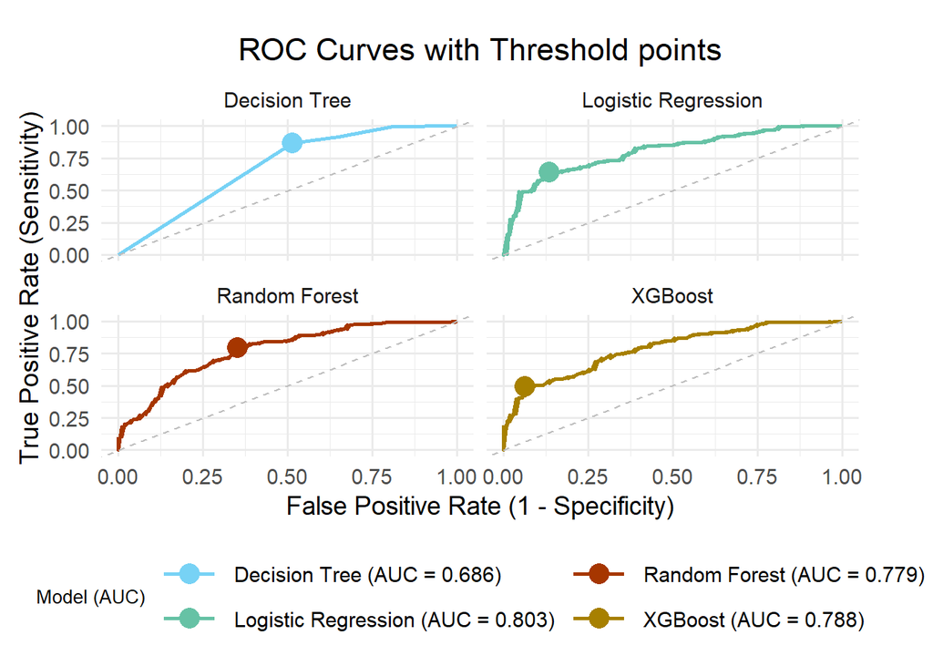

```r
# Combine ROC curves and threshold points from multiple models
all_roc_df <- bind_rows(roc_log$roc_df, roc_dt$roc_df, roc_rf$roc_df, roc_xgb$roc_df)
all_point_df <- bind_rows(roc_log$point_df, roc_dt$point_df, roc_rf$point_df, roc_xgb$point_df)


# Add label column for unified legend
all_roc_df <- all_roc_df %>%
  mutate(Label = paste0(Model, " (AUC = ", round(AUC, 3), ")"))

all_point_df <- all_point_df %>%
  left_join(all_roc_df %>% distinct(Model, Label), by = "Model")

# Plot
plot_roc <- ggplot(all_roc_df, aes(x = FPR, y = TPR, color = Label)) +
  geom_line(linewidth = 1) +
  geom_point(data = all_point_df, aes(x = FPR, y = TPR, color = Label), size = 5) +
  geom_abline(intercept = 0, slope = 1, linetype = "dashed", color = "gray") +
  facet_wrap(~Model) +
  scale_color_manual(values = c("Logistic Regression (AUC = 0.803)" = "#66C2A5",
                                "Decision Tree (AUC = 0.686)" = "#77D2F5",
                                "Random Forest (AUC = 0.779)" = "#A63600",
                                "XGBoost (AUC = 0.788)" = "#A78000")) +
  theme_minimal(base_size = 14) +
  labs(
    title = "ROC Curves with Threshold points",
    x = "False Positive Rate (1 - Specificity)",
    y = "True Positive Rate (Sensitivity)",
    color = "Model (AUC)"
  ) +
  theme(
    legend.position = "bottom",
    legend.box = "horizontal",
    legend.title = element_text(size = 10),
    legend.key.width = unit(1.2, "cm"),
    legend.spacing.x = unit(0.6, "cm"),
    plot.title = element_text(hjust = 0.5),
    plot.margin = ggplot2::margin(t = 20, r = 40, b = 10, l = 10)) +
  guides(color = guide_legend(nrow = 2))

plot_roc
```

# 6 Business Focus and Metric Evaluation

## 6.1 Business Focus

Tasty Bytes aims to boost user engagement by accurately identifying and promoting recipes that drive High website traffic at least 80% of the time.

## 6.2 Business Criteria and KPI

To evaluate models in line with business objectives which only focuses on predicting High traffic recipes, we defined business-relevant KPIs:

- **Recall <sub>High Traffic</sub> (%):** Measures how effectively the model identifies recipes that actually receive High traffic.
- **Overall Accuracy <sub>High Traffic</sub> (%):** Represents the percentage of total correct predictions - High traffic recipe.
- **F1 Score <sub>High Traffic</sub>:** The harmonic mean of precision and recall for High traffic recipes, balancing false positives and false negatives.

Higher KPI values indicate stronger alignment with user engagement, supporting Tasty Bytes in prioritizing recipes that truly resonate with the audience.

## 6.3 Business Metric Results

All models successfully met Tasty Bytes’ objective of accurately predicting High traffic recipes, with **Recall for High Traffic (%) above 80%** across the board.

- **Recall <sub>High Traffic</sub> (%):** Both Decision Tree and XGBoost lead slightly at 86.6%, followed closely by Random Forest at 85.5% and Logistic Regression at 83.1%, ensuring that the majority of high-traffic recipes are correctly identified for the homepage.
- **Overall Accuracy <sub>High Traffic</sub> (%):** Logistic Regression achieves the highest overall accuracy at 74.6%, making it the most reliable for general recipe predictions.
- **F1 Score <sub>High Traffic</sub>:** F1 scores range from 0.78 to 0.80, indicating balanced performance between precision and recall in identifying high-traffic recipes.

**Key Insights:**

- Logistic Regression offers the most balanced and interpretable predictions.
- Decision Tree and XGBoost slightly outperform in capturing high-traffic recipes, supporting Tasty Bytes’ goal of featuring the most engaging recipes and driving user traffic.

```r
predictions_list <- list(
  "Logistic Regression" = log_preds,   # replace with your predictions
  "Decision Tree"       = dt_preds,
  "Random Forest"       = rf_preds,
  "XGBoost"             = xgb_preds
)

# True labels
true_labels <- test_final$traffic

# Compute business KPIs
business_metrics_df <- compute_business_metrics(predictions_list, true_labels)

# View results
kable(business_metrics_df, caption = "Business KPIs Results") %>%
  kable_styling(full_width = F, position = "left")
```

Business KPIs Results

| Model | Accuracy | Recall_High_Traffic | F1_High_Traffic |
| --- | --- | --- | --- |
| Logistic Regression | 74.56 | 83.14 | 0.80 |
| Decision Tree | 71.73 | 86.63 | 0.79 |
| Random Forest | 71.02 | 85.47 | 0.78 |
| XGBoost | 72.08 | 86.63 | 0.79 |

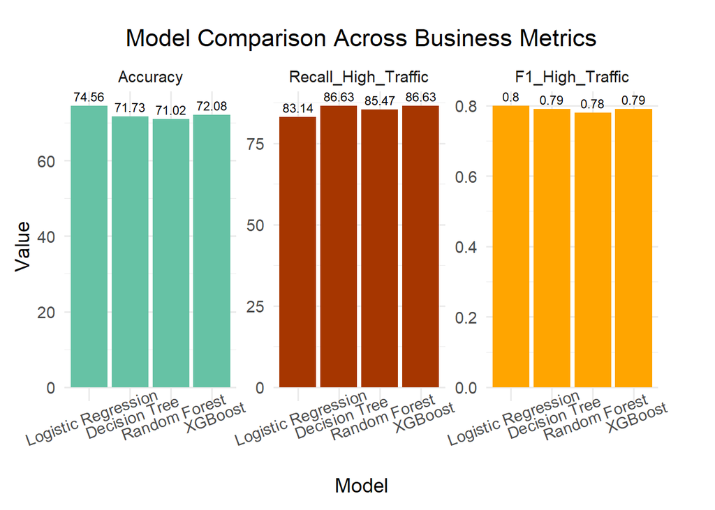

```r
# Data visuals
plot_df <- business_metrics_df %>%
  select(Model, Accuracy, Recall_High_Traffic, F1_High_Traffic) %>%
  pivot_longer(cols = -Model, names_to = "Metric", values_to = "Value") %>%
  mutate(Metric = factor(
      Metric, levels = c("Accuracy", "Recall_High_Traffic", "F1_High_Traffic")),
         Model = factor(
      Model, levels = c("Logistic Regression", "Decision Tree", "Random Forest", "XGBoost"))) %>%
  ggplot(aes(x = Model, y = Value, fill = Metric)) +
  geom_col(position = position_dodge(width = 0.8), show.legend = FALSE) +
  geom_text(aes(label = round(Value, 2)),
            position = position_dodge(width = 0.8), vjust = -0.5, size = 3) +
  facet_wrap(~Metric, scales = 'free_y') +
  scale_fill_manual(values = c(
      "Accuracy"            = "#66C2A5",
      "Recall_High_Traffic" = "#A63600",
      "F1_High_Traffic"     = "orange"
  )) +
  labs(
    title = "Model Comparison Across Business Metrics",
    x = "Model",
    y = "Value"
  ) +
  theme_minimal(base_size = 14) +
  theme(
    axis.text.x = element_text(angle = 20, hjust = 0.5),
    legend.title = element_text(size = 10),
    legend.key.width = unit(1.2, "cm"),
    legend.spacing.x = unit(0.6, "cm"),
    plot.title = element_text(hjust = 0.5),
    plot.margin = ggplot2::margin(t = 20, r = 40, b = 10, l = 10))

plot_df
```

# 7 Conclusion and Recommendations

## 7.1 Conclusion

**Project Goal**

The main objective was to predict which recipes are likely to generate high website traffic, achieving at least 80% accuracy in identifying high-traffic recipes. This enables data-driven homepage selection to boost user engagement and subscriptions.

**Project Outcome**

The Tasty Bytes project successfully developed predictive models — **Logistic Regression, Decision Tree, Random Forest, and XGBoost** — that accurately identify high-traffic recipes based on **recipe category, nutrient composition, and serving size**.

All models exceeded the **80% Recall High Traffic KPI**, confirming that the most engaging recipes can now be reliably predicted for homepage selection.

**Key Findings:**

**Traffic Prediction Drivers**

- **Recipe category** is the dominant predictor: - **High traffic:** Vegetables, Potato, Pork - **Low traffic:** Beverages, Breakfast, Chicken
- **Nutrient composition per serving** (protein, carbohydrates, calories, sugar) and serving size provide secondary influence, ensuring fair comparisons across recipes.

**Model Performance in relation to the Business goals:**

- **Recall <sub>High Traffic</sub> (%):** Decision Tree and XGBoost lead at 86.6%, followed by Random Forest (85.5%) and Logistic Regression (83.1%).
- **Overall Accuracy <sub>High Traffic</sub> (%):** Logistic Regression provides the highest overall accuracy (74.6%), ensuring reliable general predictions.
- **F1 Scores <sub>High Traffic</sub> (%):** Balanced across models (0.78–0.80), demonstrating consistent precision and recall.

These results demonstrate that recipe popularity and user engagement can now be quantitatively predicted. By leveraging these models, Tasty Bytes can confidently choose homepage recipes that are most likely to attract users, thereby maximizing traffic and subscriptions in a measurable, repeatable way.

## 7.3 Limitations

While the project aligns closely with the client’s goals, several limitations should be noted:

- **Limited Feature Set:** Only recipe category, nutrients, and serving size were used. Adding ratings, prep time, visuals, or seasonal appeal could improve predictions.
- **Imputed Data:** Missing traffic and nutrient values were filled using logical imputation, which may introduce minor bias.
- **Generalization Limits:** Some categories or seasonal recipes may be underrepresented, affecting performance on new recipes.
- **Model Interpretability vs Accuracy:** Random Forest is less interpretable than Logistic Regression.
- **Scope of Predictions:** Current predictions classify recipes as high or low traffic only, without measuring deeper engagement indicators (e.g., dwell time, repeat visits, conversions).

## 7.4 Next Steps

To improve the model accuracy and strengthen the link between predictions and business outcomes, the following steps are advised:

- **Track Real-World Performance:** Continuously monitor Overall Accuracy <sub>High Traffic</sub> (%), F1 score <sub>High Traffic</sub> (%), and Recall <sub>High Traffic</sub> (%) rate to ensure the models maintain reliability in live deployment.
- **Refine Success Metrics:** Expand business KPIs beyond traffic — include click-through rate, conversion rate, and subscription uplift — to quantify the true impact on company growth.
- **Retrain and Optimize Models:** Update models regularly with new data to reflect changing trends.
- **Feature Expansion:** Incorporate seasonality, user engagement, preparation difficulty, and visual appeal.
- **A/B Test Homepage Strategies:** Compare model-driven selections with manual selections to measure improvements.
- **Continuous Business Alignment:** Ensure ongoing collaboration between data science and marketing teams to apply model insights effectively.